# Project: NoShowAppointments Data Analysis

- Introduction
- Data Wrangling
- Exploratory Data Analysis
- Conclusions

## Introduction

I will analyse data set associated with medical appointments that focused on whether or not patients show up for their appointment

> - What Kind of Patiant that doesn't show up?(age, Gender)
> - what factors make patients don't show up for their scheduled appointment
> - Does number of the days between the ScheduledDay and the AppointmentDay affect on patient show up for their scheduled appointment
> - Does kind of disease affect patient show up for their scheduled appointment?

```python
import pandas as pd
import numpy as np
import matplotlib.pyplot as plt
% matplotlib inline
import seaborn as sns
import datetime
```

## Data Wrangling

### General Properties

```python
#Data_Gathering from noshowappointments-kagglev2-may-2016.csv
appoint_df = pd.read_csv('noshowappointments-kagglev2-may-2016.csv')
appoint_df
```

|  | PatientId | AppointmentID | Gender | ScheduledDay | AppointmentDay | Age | Neighbourhood | Scholarship | Hipertension | Diabetes | Alcoholism | Handcap | SMS_received | No-show |
| --- | --- | --- | --- | --- | --- | --- | --- | --- | --- | --- | --- | --- | --- | --- |
| 0 | 2.987250e+13 | 5642903 | F | 2016-04-29T18:38:08Z | 2016-04-29T00:00:00Z | 62 | JARDIM DA PENHA | 0 | 1 | 0 | 0 | 0 | 0 | No |
| 1 | 5.589978e+14 | 5642503 | M | 2016-04-29T16:08:27Z | 2016-04-29T00:00:00Z | 56 | JARDIM DA PENHA | 0 | 0 | 0 | 0 | 0 | 0 | No |
| 2 | 4.262962e+12 | 5642549 | F | 2016-04-29T16:19:04Z | 2016-04-29T00:00:00Z | 62 | MATA DA PRAIA | 0 | 0 | 0 | 0 | 0 | 0 | No |
| 3 | 8.679512e+11 | 5642828 | F | 2016-04-29T17:29:31Z | 2016-04-29T00:00:00Z | 8 | PONTAL DE CAMBURI | 0 | 0 | 0 | 0 | 0 | 0 | No |
| 4 | 8.841186e+12 | 5642494 | F | 2016-04-29T16:07:23Z | 2016-04-29T00:00:00Z | 56 | JARDIM DA PENHA | 0 | 1 | 1 | 0 | 0 | 0 | No |
| 5 | 9.598513e+13 | 5626772 | F | 2016-04-27T08:36:51Z | 2016-04-29T00:00:00Z | 76 | REPÚBLICA | 0 | 1 | 0 | 0 | 0 | 0 | No |
| 6 | 7.336882e+14 | 5630279 | F | 2016-04-27T15:05:12Z | 2016-04-29T00:00:00Z | 23 | GOIABEIRAS | 0 | 0 | 0 | 0 | 0 | 0 | Yes |
| 7 | 3.449833e+12 | 5630575 | F | 2016-04-27T15:39:58Z | 2016-04-29T00:00:00Z | 39 | GOIABEIRAS | 0 | 0 | 0 | 0 | 0 | 0 | Yes |
| 8 | 5.639473e+13 | 5638447 | F | 2016-04-29T08:02:16Z | 2016-04-29T00:00:00Z | 21 | ANDORINHAS | 0 | 0 | 0 | 0 | 0 | 0 | No |
| 9 | 7.812456e+13 | 5629123 | F | 2016-04-27T12:48:25Z | 2016-04-29T00:00:00Z | 19 | CONQUISTA | 0 | 0 | 0 | 0 | 0 | 0 | No |
| 10 | 7.345362e+14 | 5630213 | F | 2016-04-27T14:58:11Z | 2016-04-29T00:00:00Z | 30 | NOVA PALESTINA | 0 | 0 | 0 | 0 | 0 | 0 | No |
| 11 | 7.542951e+12 | 5620163 | M | 2016-04-26T08:44:12Z | 2016-04-29T00:00:00Z | 29 | NOVA PALESTINA | 0 | 0 | 0 | 0 | 0 | 1 | Yes |
| 12 | 5.666548e+14 | 5634718 | F | 2016-04-28T11:33:51Z | 2016-04-29T00:00:00Z | 22 | NOVA PALESTINA | 1 | 0 | 0 | 0 | 0 | 0 | No |
| 13 | 9.113946e+14 | 5636249 | M | 2016-04-28T14:52:07Z | 2016-04-29T00:00:00Z | 28 | NOVA PALESTINA | 0 | 0 | 0 | 0 | 0 | 0 | No |
| 14 | 9.988472e+13 | 5633951 | F | 2016-04-28T10:06:24Z | 2016-04-29T00:00:00Z | 54 | NOVA PALESTINA | 0 | 0 | 0 | 0 | 0 | 0 | No |
| 15 | 9.994839e+10 | 5620206 | F | 2016-04-26T08:47:27Z | 2016-04-29T00:00:00Z | 15 | NOVA PALESTINA | 0 | 0 | 0 | 0 | 0 | 1 | No |
| 16 | 8.457439e+13 | 5633121 | M | 2016-04-28T08:51:47Z | 2016-04-29T00:00:00Z | 50 | NOVA PALESTINA | 0 | 0 | 0 | 0 | 0 | 0 | No |
| 17 | 1.479497e+13 | 5633460 | F | 2016-04-28T09:28:57Z | 2016-04-29T00:00:00Z | 40 | CONQUISTA | 1 | 0 | 0 | 0 | 0 | 0 | Yes |
| 18 | 1.713538e+13 | 5621836 | F | 2016-04-26T10:54:18Z | 2016-04-29T00:00:00Z | 30 | NOVA PALESTINA | 1 | 0 | 0 | 0 | 0 | 1 | No |
| 19 | 7.223289e+12 | 5640433 | F | 2016-04-29T10:43:14Z | 2016-04-29T00:00:00Z | 46 | DA PENHA | 0 | 0 | 0 | 0 | 0 | 0 | No |
| 20 | 6.222575e+14 | 5626083 | F | 2016-04-27T07:51:14Z | 2016-04-29T00:00:00Z | 30 | NOVA PALESTINA | 0 | 0 | 0 | 0 | 0 | 0 | Yes |
| 21 | 1.215484e+13 | 5628338 | F | 2016-04-27T10:50:45Z | 2016-04-29T00:00:00Z | 4 | CONQUISTA | 0 | 0 | 0 | 0 | 0 | 0 | Yes |
| 22 | 8.632298e+14 | 5616091 | M | 2016-04-25T13:29:16Z | 2016-04-29T00:00:00Z | 13 | CONQUISTA | 0 | 0 | 0 | 0 | 0 | 1 | Yes |
| 23 | 2.137540e+14 | 5634142 | F | 2016-04-28T10:27:05Z | 2016-04-29T00:00:00Z | 46 | CONQUISTA | 0 | 0 | 0 | 0 | 0 | 0 | No |
| 24 | 8.734858e+12 | 5641780 | F | 2016-04-29T14:19:19Z | 2016-04-29T00:00:00Z | 65 | TABUAZEIRO | 0 | 0 | 0 | 0 | 0 | 0 | No |
| 25 | 5.819370e+12 | 5624020 | M | 2016-04-26T15:04:17Z | 2016-04-29T00:00:00Z | 46 | CONQUISTA | 0 | 1 | 0 | 0 | 0 | 1 | No |
| 26 | 2.578785e+10 | 5641781 | F | 2016-04-29T14:19:42Z | 2016-04-29T00:00:00Z | 45 | BENTO FERREIRA | 0 | 1 | 0 | 0 | 0 | 0 | No |
| 27 | 1.215484e+13 | 5628345 | F | 2016-04-27T10:51:45Z | 2016-04-29T00:00:00Z | 4 | CONQUISTA | 0 | 0 | 0 | 0 | 0 | 0 | No |
| 28 | 5.926172e+12 | 5642400 | M | 2016-04-29T15:48:02Z | 2016-04-29T00:00:00Z | 51 | SÃO PEDRO | 0 | 0 | 0 | 0 | 0 | 0 | No |
| 29 | 1.225776e+12 | 5642186 | F | 2016-04-29T15:16:29Z | 2016-04-29T00:00:00Z | 32 | SANTA MARTHA | 0 | 0 | 0 | 0 | 0 | 0 | No |
| ... | ... | ... | ... | ... | ... | ... | ... | ... | ... | ... | ... | ... | ... | ... |
| 110497 | 7.935892e+14 | 5757745 | M | 2016-06-01T09:46:33Z | 2016-06-01T00:00:00Z | 76 | MARIA ORTIZ | 0 | 0 | 0 | 0 | 0 | 0 | No |
| 110498 | 9.433654e+13 | 5787655 | F | 2016-06-08T10:21:14Z | 2016-06-08T00:00:00Z | 59 | MARIA ORTIZ | 0 | 0 | 0 | 0 | 0 | 0 | No |
| 110499 | 8.219692e+14 | 5757697 | F | 2016-06-01T09:42:56Z | 2016-06-01T00:00:00Z | 66 | MARIA ORTIZ | 0 | 1 | 1 | 0 | 0 | 0 | No |
| 110500 | 4.434384e+14 | 5787233 | F | 2016-06-08T09:35:13Z | 2016-06-08T00:00:00Z | 59 | MARIA ORTIZ | 0 | 0 | 0 | 0 | 0 | 0 | No |
| 110501 | 4.544252e+11 | 5758133 | M | 2016-06-01T10:19:12Z | 2016-06-01T00:00:00Z | 44 | MARIA ORTIZ | 0 | 0 | 0 | 0 | 0 | 0 | No |
| 110502 | 7.316229e+14 | 5787937 | F | 2016-06-08T10:50:42Z | 2016-06-08T00:00:00Z | 22 | GOIABEIRAS | 0 | 0 | 0 | 0 | 0 | 0 | No |
| 110503 | 2.362182e+13 | 5759473 | F | 2016-06-01T13:00:36Z | 2016-06-01T00:00:00Z | 64 | SOLON BORGES | 0 | 0 | 0 | 0 | 0 | 0 | No |
| 110504 | 9.947983e+12 | 5788052 | F | 2016-06-08T11:06:21Z | 2016-06-08T00:00:00Z | 4 | MARIA ORTIZ | 0 | 0 | 0 | 0 | 0 | 0 | No |
| 110505 | 5.667344e+13 | 5758455 | F | 2016-06-01T10:45:50Z | 2016-06-01T00:00:00Z | 55 | MARIA ORTIZ | 0 | 0 | 0 | 0 | 0 | 0 | No |
| 110506 | 8.973883e+11 | 5758779 | M | 2016-06-01T11:09:20Z | 2016-06-01T00:00:00Z | 5 | MARIA ORTIZ | 0 | 0 | 0 | 0 | 0 | 0 | No |
| 110507 | 4.769462e+14 | 5786918 | F | 2016-06-08T09:04:18Z | 2016-06-08T00:00:00Z | 0 | MARIA ORTIZ | 0 | 0 | 0 | 0 | 0 | 0 | No |
| 110508 | 9.433654e+13 | 5757656 | F | 2016-06-01T09:41:00Z | 2016-06-01T00:00:00Z | 59 | MARIA ORTIZ | 0 | 0 | 0 | 0 | 0 | 0 | No |
| 110509 | 4.952968e+14 | 5786750 | M | 2016-06-08T08:50:51Z | 2016-06-08T00:00:00Z | 33 | MARIA ORTIZ | 0 | 0 | 0 | 0 | 0 | 0 | No |
| 110510 | 2.362182e+13 | 5757587 | F | 2016-06-01T09:35:48Z | 2016-06-01T00:00:00Z | 64 | SOLON BORGES | 0 | 0 | 0 | 0 | 0 | 0 | No |
| 110511 | 8.235996e+11 | 5786742 | F | 2016-06-08T08:50:20Z | 2016-06-08T00:00:00Z | 14 | MARIA ORTIZ | 0 | 0 | 0 | 0 | 0 | 0 | No |
| 110512 | 9.876246e+13 | 5786368 | F | 2016-06-08T08:20:01Z | 2016-06-08T00:00:00Z | 41 | MARIA ORTIZ | 0 | 0 | 0 | 0 | 0 | 0 | No |
| 110513 | 8.674778e+13 | 5785964 | M | 2016-06-08T07:52:55Z | 2016-06-08T00:00:00Z | 2 | ANTÔNIO HONÓRIO | 0 | 0 | 0 | 0 | 0 | 0 | No |
| 110514 | 2.695685e+12 | 5786567 | F | 2016-06-08T08:35:31Z | 2016-06-08T00:00:00Z | 58 | MARIA ORTIZ | 0 | 0 | 0 | 0 | 0 | 0 | No |
| 110515 | 6.456342e+14 | 5778621 | M | 2016-06-06T15:58:05Z | 2016-06-08T00:00:00Z | 33 | MARIA ORTIZ | 0 | 1 | 0 | 0 | 0 | 0 | Yes |
| 110516 | 6.923772e+13 | 5780205 | F | 2016-06-07T07:45:16Z | 2016-06-08T00:00:00Z | 37 | MARIA ORTIZ | 0 | 0 | 0 | 0 | 0 | 0 | Yes |
| 110517 | 5.574942e+12 | 5780122 | F | 2016-06-07T07:38:34Z | 2016-06-07T00:00:00Z | 19 | MARIA ORTIZ | 0 | 0 | 0 | 0 | 0 | 0 | No |
| 110518 | 7.263315e+13 | 5630375 | F | 2016-04-27T15:15:06Z | 2016-06-07T00:00:00Z | 50 | MARIA ORTIZ | 0 | 0 | 0 | 0 | 0 | 1 | No |
| 110519 | 6.542388e+13 | 5630447 | F | 2016-04-27T15:23:14Z | 2016-06-07T00:00:00Z | 22 | MARIA ORTIZ | 0 | 0 | 0 | 0 | 0 | 1 | No |
| 110520 | 9.969977e+14 | 5650534 | F | 2016-05-03T07:51:47Z | 2016-06-07T00:00:00Z | 42 | MARIA ORTIZ | 0 | 0 | 0 | 0 | 0 | 1 | No |
| 110521 | 3.635534e+13 | 5651072 | F | 2016-05-03T08:23:40Z | 2016-06-07T00:00:00Z | 53 | MARIA ORTIZ | 0 | 0 | 0 | 0 | 0 | 1 | No |
| 110522 | 2.572134e+12 | 5651768 | F | 2016-05-03T09:15:35Z | 2016-06-07T00:00:00Z | 56 | MARIA ORTIZ | 0 | 0 | 0 | 0 | 0 | 1 | No |
| 110523 | 3.596266e+12 | 5650093 | F | 2016-05-03T07:27:33Z | 2016-06-07T00:00:00Z | 51 | MARIA ORTIZ | 0 | 0 | 0 | 0 | 0 | 1 | No |
| 110524 | 1.557663e+13 | 5630692 | F | 2016-04-27T16:03:52Z | 2016-06-07T00:00:00Z | 21 | MARIA ORTIZ | 0 | 0 | 0 | 0 | 0 | 1 | No |
| 110525 | 9.213493e+13 | 5630323 | F | 2016-04-27T15:09:23Z | 2016-06-07T00:00:00Z | 38 | MARIA ORTIZ | 0 | 0 | 0 | 0 | 0 | 1 | No |
| 110526 | 3.775115e+14 | 5629448 | F | 2016-04-27T13:30:56Z | 2016-06-07T00:00:00Z | 54 | MARIA ORTIZ | 0 | 0 | 0 | 0 | 0 | 1 | No |

110527 rows × 14 columns

### Assessing Data

###### Investigate Data using (.info())and( .describe()),(.sample()) methods

```python
# Find columns with missing data and data type problem
appoint_df.info()
```

```
<class 'pandas.core.frame.DataFrame'>
RangeIndex: 110527 entries, 0 to 110526
Data columns (total 14 columns):
PatientId         110527 non-null float64
AppointmentID     110527 non-null int64
Gender            110527 non-null object
ScheduledDay      110527 non-null object
AppointmentDay    110527 non-null object
Age               110527 non-null int64
Neighbourhood     110527 non-null object
Scholarship       110527 non-null int64
Hipertension      110527 non-null int64
Diabetes          110527 non-null int64
Alcoholism        110527 non-null int64
Handcap           110527 non-null int64
SMS_received      110527 non-null int64
No-show           110527 non-null object
dtypes: float64(1), int64(8), object(5)
memory usage: 11.8+ MB
```

```python
# data frame describtive statistics
appoint_df.describe()
```

|  | PatientId | AppointmentID | Age | Scholarship | Hipertension | Diabetes | Alcoholism | Handcap | SMS_received |
| --- | --- | --- | --- | --- | --- | --- | --- | --- | --- |
| count | 1.105270e+05 | 1.105270e+05 | 110527.000000 | 110527.000000 | 110527.000000 | 110527.000000 | 110527.000000 | 110527.000000 | 110527.000000 |
| mean | 1.474963e+14 | 5.675305e+06 | 37.088874 | 0.098266 | 0.197246 | 0.071865 | 0.030400 | 0.022248 | 0.321026 |
| std | 2.560949e+14 | 7.129575e+04 | 23.110205 | 0.297675 | 0.397921 | 0.258265 | 0.171686 | 0.161543 | 0.466873 |
| min | 3.921784e+04 | 5.030230e+06 | -1.000000 | 0.000000 | 0.000000 | 0.000000 | 0.000000 | 0.000000 | 0.000000 |
| 25% | 4.172614e+12 | 5.640286e+06 | 18.000000 | 0.000000 | 0.000000 | 0.000000 | 0.000000 | 0.000000 | 0.000000 |
| 50% | 3.173184e+13 | 5.680573e+06 | 37.000000 | 0.000000 | 0.000000 | 0.000000 | 0.000000 | 0.000000 | 0.000000 |
| 75% | 9.439172e+13 | 5.725524e+06 | 55.000000 | 0.000000 | 0.000000 | 0.000000 | 0.000000 | 0.000000 | 1.000000 |
| max | 9.999816e+14 | 5.790484e+06 | 115.000000 | 1.000000 | 1.000000 | 1.000000 | 1.000000 | 4.000000 | 1.000000 |

```python
#Check the data_frame data
appoint_df.sample(25)
```

|  | PatientId | AppointmentID | Gender | ScheduledDay | AppointmentDay | Age | Neighbourhood | Scholarship | Hipertension | Diabetes | Alcoholism | Handcap | SMS_received | No-show |
| --- | --- | --- | --- | --- | --- | --- | --- | --- | --- | --- | --- | --- | --- | --- |
| 83374 | 7.112196e+14 | 5703958 | F | 2016-05-16T14:47:08Z | 2016-05-30T00:00:00Z | 34 | ITARARÉ | 0 | 0 | 0 | 0 | 0 | 1 | No |
| 29466 | 7.913942e+13 | 5598438 | F | 2016-04-19T07:34:43Z | 2016-05-04T00:00:00Z | 20 | ROMÃO | 0 | 0 | 0 | 0 | 0 | 1 | No |
| 50690 | 3.831873e+13 | 5652223 | M | 2016-05-03T09:50:03Z | 2016-05-19T00:00:00Z | 55 | SANTA CECÍLIA | 0 | 1 | 0 | 0 | 0 | 0 | No |
| 57337 | 9.439578e+13 | 5539748 | F | 2016-04-01T15:42:39Z | 2016-05-05T00:00:00Z | 19 | MARIA ORTIZ | 0 | 0 | 0 | 0 | 0 | 1 | Yes |
| 67072 | 1.883758e+13 | 5698418 | M | 2016-05-16T07:33:37Z | 2016-05-16T00:00:00Z | 58 | JARDIM CAMBURI | 0 | 0 | 0 | 0 | 0 | 0 | No |
| 45430 | 7.199714e+13 | 5616042 | M | 2016-04-25T13:24:47Z | 2016-05-09T00:00:00Z | 0 | REDENÇÃO | 0 | 0 | 0 | 0 | 0 | 0 | Yes |
| 14045 | 5.725885e+14 | 5687844 | F | 2016-05-11T16:51:17Z | 2016-05-24T00:00:00Z | 53 | SÃO CRISTÓVÃO | 0 | 0 | 0 | 0 | 0 | 1 | Yes |
| 77086 | 4.226339e+14 | 5669141 | F | 2016-05-06T10:24:06Z | 2016-05-31T00:00:00Z | 51 | SANTO ANTÔNIO | 0 | 0 | 0 | 0 | 0 | 0 | No |
| 10559 | 6.859959e+14 | 5520873 | M | 2016-03-29T10:38:36Z | 2016-05-10T00:00:00Z | 65 | CRUZAMENTO | 0 | 0 | 1 | 0 | 0 | 1 | Yes |
| 28941 | 1.438131e+13 | 5643644 | F | 2016-05-02T07:42:14Z | 2016-05-12T00:00:00Z | 20 | ROMÃO | 0 | 0 | 0 | 0 | 0 | 1 | No |
| 68398 | 3.758218e+13 | 5690732 | F | 2016-05-12T10:33:27Z | 2016-05-12T00:00:00Z | 41 | MARIA ORTIZ | 0 | 0 | 0 | 0 | 0 | 0 | No |
| 77397 | 7.165864e+14 | 5663702 | F | 2016-05-05T10:25:17Z | 2016-05-25T00:00:00Z | 4 | SANTO ANTÔNIO | 0 | 0 | 0 | 0 | 0 | 1 | No |
| 1298 | 4.485669e+11 | 5520171 | M | 2016-03-29T09:38:20Z | 2016-04-29T00:00:00Z | 63 | MARIA ORTIZ | 0 | 0 | 0 | 0 | 0 | 1 | No |
| 89663 | 8.728992e+13 | 5746636 | M | 2016-05-30T14:18:12Z | 2016-06-06T00:00:00Z | 7 | SÃO PEDRO | 0 | 0 | 0 | 0 | 0 | 1 | No |
| 94701 | 3.517516e+13 | 5774472 | F | 2016-06-06T08:18:06Z | 2016-06-07T00:00:00Z | 39 | REDENÇÃO | 1 | 0 | 0 | 1 | 0 | 0 | Yes |
| 92351 | 5.115886e+14 | 5583063 | F | 2016-04-14T10:23:47Z | 2016-06-06T00:00:00Z | 38 | SANTA MARTHA | 0 | 1 | 1 | 0 | 0 | 0 | No |
| 24206 | 8.343142e+14 | 5607354 | F | 2016-04-20T11:36:02Z | 2016-05-17T00:00:00Z | 13 | SÃO PEDRO | 0 | 0 | 0 | 0 | 0 | 0 | No |
| 66778 | 6.554977e+11 | 5721872 | F | 2016-05-19T18:43:56Z | 2016-05-19T00:00:00Z | 59 | JARDIM CAMBURI | 0 | 1 | 0 | 0 | 0 | 0 | No |
| 14781 | 8.126132e+09 | 5711487 | F | 2016-05-18T07:41:14Z | 2016-05-18T00:00:00Z | 0 | DO QUADRO | 0 | 0 | 0 | 0 | 0 | 0 | No |
| 20389 | 6.489489e+12 | 5659101 | F | 2016-05-04T13:10:21Z | 2016-05-09T00:00:00Z | 44 | ANDORINHAS | 1 | 1 | 0 | 1 | 0 | 0 | Yes |
| 45029 | 2.284168e+14 | 5616371 | F | 2016-04-25T14:02:57Z | 2016-05-10T00:00:00Z | 57 | SANTO ANTÔNIO | 0 | 0 | 0 | 0 | 0 | 1 | No |
| 24038 | 9.995939e+12 | 5634349 | F | 2016-04-28T10:48:56Z | 2016-05-24T00:00:00Z | 23 | SANTA MARTHA | 0 | 0 | 0 | 0 | 0 | 1 | No |
| 107740 | 5.837441e+13 | 5743260 | M | 2016-05-30T08:50:53Z | 2016-06-01T00:00:00Z | 51 | SANTA CLARA | 0 | 1 | 1 | 0 | 0 | 0 | Yes |
| 11635 | 9.233616e+13 | 5726720 | M | 2016-05-20T14:11:26Z | 2016-05-25T00:00:00Z | 38 | MARUÍPE | 0 | 0 | 0 | 0 | 0 | 1 | No |
| 69776 | 3.183387e+14 | 5706433 | F | 2016-05-17T08:18:50Z | 2016-05-17T00:00:00Z | 55 | PRAIA DO CANTO | 0 | 0 | 0 | 0 | 0 | 0 | No |

###### Delve deeper into the Age variable

```python
# Investigate Age with inacurate data
appoint_df[appoint_df['Age']<0]
```

|  | PatientId | AppointmentID | Gender | ScheduledDay | AppointmentDay | Age | Neighbourhood | Scholarship | Hipertension | Diabetes | Alcoholism | Handcap | SMS_received | No-show |
| --- | --- | --- | --- | --- | --- | --- | --- | --- | --- | --- | --- | --- | --- | --- |
| 99832 | 4.659432e+14 | 5775010 | F | 2016-06-06T08:58:13Z | 2016-06-06T00:00:00Z | -1 | ROMÃO | 0 | 0 | 0 | 0 | 0 | 0 | No |

```python
# Investigate Age bigger than 100 and find if they are inacurate data or not
appoint_df[appoint_df['Age']>=100 ]
```

|  | PatientId | AppointmentID | Gender | ScheduledDay | AppointmentDay | Age | Neighbourhood | Scholarship | Hipertension | Diabetes | Alcoholism | Handcap | SMS_received | No-show |
| --- | --- | --- | --- | --- | --- | --- | --- | --- | --- | --- | --- | --- | --- | --- |
| 58014 | 9.762948e+14 | 5651757 | F | 2016-05-03T09:14:53Z | 2016-05-03T00:00:00Z | 102 | CONQUISTA | 0 | 0 | 0 | 0 | 0 | 0 | No |
| 63912 | 3.196321e+13 | 5700278 | F | 2016-05-16T09:17:44Z | 2016-05-19T00:00:00Z | 115 | ANDORINHAS | 0 | 0 | 0 | 0 | 1 | 0 | Yes |
| 63915 | 3.196321e+13 | 5700279 | F | 2016-05-16T09:17:44Z | 2016-05-19T00:00:00Z | 115 | ANDORINHAS | 0 | 0 | 0 | 0 | 1 | 0 | Yes |
| 68127 | 3.196321e+13 | 5562812 | F | 2016-04-08T14:29:17Z | 2016-05-16T00:00:00Z | 115 | ANDORINHAS | 0 | 0 | 0 | 0 | 1 | 0 | Yes |
| 76284 | 3.196321e+13 | 5744037 | F | 2016-05-30T09:44:51Z | 2016-05-30T00:00:00Z | 115 | ANDORINHAS | 0 | 0 | 0 | 0 | 1 | 0 | No |
| 79270 | 9.739430e+12 | 5747809 | M | 2016-05-30T16:21:56Z | 2016-05-31T00:00:00Z | 100 | TABUAZEIRO | 0 | 0 | 0 | 0 | 1 | 0 | No |
| 79272 | 9.739430e+12 | 5747808 | M | 2016-05-30T16:21:56Z | 2016-05-31T00:00:00Z | 100 | TABUAZEIRO | 0 | 0 | 0 | 0 | 1 | 0 | No |
| 90372 | 2.342836e+11 | 5751563 | F | 2016-05-31T10:19:49Z | 2016-06-02T00:00:00Z | 102 | MARIA ORTIZ | 0 | 0 | 0 | 0 | 0 | 0 | No |
| 92084 | 5.578313e+13 | 5670914 | F | 2016-05-06T14:55:36Z | 2016-06-03T00:00:00Z | 100 | ANTÔNIO HONÓRIO | 0 | 0 | 0 | 0 | 0 | 1 | No |
| 97666 | 7.482346e+14 | 5717451 | F | 2016-05-19T07:57:56Z | 2016-06-03T00:00:00Z | 115 | SÃO JOSÉ | 0 | 1 | 0 | 0 | 0 | 1 | No |
| 108506 | 3.939642e+11 | 5721152 | F | 2016-05-19T15:32:09Z | 2016-06-01T00:00:00Z | 100 | MARUÍPE | 0 | 0 | 0 | 0 | 0 | 0 | No |

###### Delve deeper into the No-show variable

```python
# check kind of data of patients that show or not
appoint_df['No-show'].value_counts()
```

```
No     88208
Yes    22319
Name: No-show, dtype: int64
```

```python
# check the duplicated data
appoint_df.duplicated().value_counts()
```

```
False    110527
dtype: int64
```

```python
#check data for each disease
colum = ['Hipertension','Diabetes','Alcoholism','Handcap']
for col in colum:
    print(appoint_df[col].value_counts())
```

```
0    88726
1    21801
Name: Hipertension, dtype: int64
0    102584
1      7943
Name: Diabetes, dtype: int64
0    107167
1      3360
Name: Alcoholism, dtype: int64
0    108286
1      2042
2       183
3        13
4         3
Name: Handcap, dtype: int64
```

### appoint_df Assessment Summary

##### Quality issues:

> 1. Erroneous datatypes (ScheduledDay and AppointmentDay are string not datetime format,PatientId is float).
> 2. Inconsistent represent of records as (0) in (Hipertension, Diabetes, Alcoholism, Handcap)
> 3. Inaccurate Age=-1
> 4. Inaccurate data in Handcap and SMS_received [Handcap is binary, SMS is no binary, some people receive more 0 1 or 2 sms messages] https://www.kaggle.com/joniarroba/noshowappointments/discussion/30844 the 2 columns' data sweeped

#### Tidiness issues

> 1. colums header are, values not variable(Hipertension, Diabetes, Alcoholism, Handcap)disease

### Data Cleaning

```python
# make copy of our data for cleaning
df_clean=appoint_df.copy()
```

##### Quality issues:

> - Inaccurate data in ['Handcap' and 'SMS_received'], the 2 columns' data sweeped

```python
df_clean
```

|  | PatientId | AppointmentID | Gender | ScheduledDay | AppointmentDay | Age | Neighbourhood | Scholarship | Hipertension | Diabetes | Alcoholism | Handcap | SMS_received | No-show |
| --- | --- | --- | --- | --- | --- | --- | --- | --- | --- | --- | --- | --- | --- | --- |
| 0 | 2.987250e+13 | 5642903 | F | 2016-04-29T18:38:08Z | 2016-04-29T00:00:00Z | 62 | JARDIM DA PENHA | 0 | 1 | 0 | 0 | 0 | 0 | No |
| 1 | 5.589978e+14 | 5642503 | M | 2016-04-29T16:08:27Z | 2016-04-29T00:00:00Z | 56 | JARDIM DA PENHA | 0 | 0 | 0 | 0 | 0 | 0 | No |
| 2 | 4.262962e+12 | 5642549 | F | 2016-04-29T16:19:04Z | 2016-04-29T00:00:00Z | 62 | MATA DA PRAIA | 0 | 0 | 0 | 0 | 0 | 0 | No |
| 3 | 8.679512e+11 | 5642828 | F | 2016-04-29T17:29:31Z | 2016-04-29T00:00:00Z | 8 | PONTAL DE CAMBURI | 0 | 0 | 0 | 0 | 0 | 0 | No |
| 4 | 8.841186e+12 | 5642494 | F | 2016-04-29T16:07:23Z | 2016-04-29T00:00:00Z | 56 | JARDIM DA PENHA | 0 | 1 | 1 | 0 | 0 | 0 | No |
| 5 | 9.598513e+13 | 5626772 | F | 2016-04-27T08:36:51Z | 2016-04-29T00:00:00Z | 76 | REPÚBLICA | 0 | 1 | 0 | 0 | 0 | 0 | No |
| 6 | 7.336882e+14 | 5630279 | F | 2016-04-27T15:05:12Z | 2016-04-29T00:00:00Z | 23 | GOIABEIRAS | 0 | 0 | 0 | 0 | 0 | 0 | Yes |
| 7 | 3.449833e+12 | 5630575 | F | 2016-04-27T15:39:58Z | 2016-04-29T00:00:00Z | 39 | GOIABEIRAS | 0 | 0 | 0 | 0 | 0 | 0 | Yes |
| 8 | 5.639473e+13 | 5638447 | F | 2016-04-29T08:02:16Z | 2016-04-29T00:00:00Z | 21 | ANDORINHAS | 0 | 0 | 0 | 0 | 0 | 0 | No |
| 9 | 7.812456e+13 | 5629123 | F | 2016-04-27T12:48:25Z | 2016-04-29T00:00:00Z | 19 | CONQUISTA | 0 | 0 | 0 | 0 | 0 | 0 | No |
| 10 | 7.345362e+14 | 5630213 | F | 2016-04-27T14:58:11Z | 2016-04-29T00:00:00Z | 30 | NOVA PALESTINA | 0 | 0 | 0 | 0 | 0 | 0 | No |
| 11 | 7.542951e+12 | 5620163 | M | 2016-04-26T08:44:12Z | 2016-04-29T00:00:00Z | 29 | NOVA PALESTINA | 0 | 0 | 0 | 0 | 0 | 1 | Yes |
| 12 | 5.666548e+14 | 5634718 | F | 2016-04-28T11:33:51Z | 2016-04-29T00:00:00Z | 22 | NOVA PALESTINA | 1 | 0 | 0 | 0 | 0 | 0 | No |
| 13 | 9.113946e+14 | 5636249 | M | 2016-04-28T14:52:07Z | 2016-04-29T00:00:00Z | 28 | NOVA PALESTINA | 0 | 0 | 0 | 0 | 0 | 0 | No |
| 14 | 9.988472e+13 | 5633951 | F | 2016-04-28T10:06:24Z | 2016-04-29T00:00:00Z | 54 | NOVA PALESTINA | 0 | 0 | 0 | 0 | 0 | 0 | No |
| 15 | 9.994839e+10 | 5620206 | F | 2016-04-26T08:47:27Z | 2016-04-29T00:00:00Z | 15 | NOVA PALESTINA | 0 | 0 | 0 | 0 | 0 | 1 | No |
| 16 | 8.457439e+13 | 5633121 | M | 2016-04-28T08:51:47Z | 2016-04-29T00:00:00Z | 50 | NOVA PALESTINA | 0 | 0 | 0 | 0 | 0 | 0 | No |
| 17 | 1.479497e+13 | 5633460 | F | 2016-04-28T09:28:57Z | 2016-04-29T00:00:00Z | 40 | CONQUISTA | 1 | 0 | 0 | 0 | 0 | 0 | Yes |
| 18 | 1.713538e+13 | 5621836 | F | 2016-04-26T10:54:18Z | 2016-04-29T00:00:00Z | 30 | NOVA PALESTINA | 1 | 0 | 0 | 0 | 0 | 1 | No |
| 19 | 7.223289e+12 | 5640433 | F | 2016-04-29T10:43:14Z | 2016-04-29T00:00:00Z | 46 | DA PENHA | 0 | 0 | 0 | 0 | 0 | 0 | No |
| 20 | 6.222575e+14 | 5626083 | F | 2016-04-27T07:51:14Z | 2016-04-29T00:00:00Z | 30 | NOVA PALESTINA | 0 | 0 | 0 | 0 | 0 | 0 | Yes |
| 21 | 1.215484e+13 | 5628338 | F | 2016-04-27T10:50:45Z | 2016-04-29T00:00:00Z | 4 | CONQUISTA | 0 | 0 | 0 | 0 | 0 | 0 | Yes |
| 22 | 8.632298e+14 | 5616091 | M | 2016-04-25T13:29:16Z | 2016-04-29T00:00:00Z | 13 | CONQUISTA | 0 | 0 | 0 | 0 | 0 | 1 | Yes |
| 23 | 2.137540e+14 | 5634142 | F | 2016-04-28T10:27:05Z | 2016-04-29T00:00:00Z | 46 | CONQUISTA | 0 | 0 | 0 | 0 | 0 | 0 | No |
| 24 | 8.734858e+12 | 5641780 | F | 2016-04-29T14:19:19Z | 2016-04-29T00:00:00Z | 65 | TABUAZEIRO | 0 | 0 | 0 | 0 | 0 | 0 | No |
| 25 | 5.819370e+12 | 5624020 | M | 2016-04-26T15:04:17Z | 2016-04-29T00:00:00Z | 46 | CONQUISTA | 0 | 1 | 0 | 0 | 0 | 1 | No |
| 26 | 2.578785e+10 | 5641781 | F | 2016-04-29T14:19:42Z | 2016-04-29T00:00:00Z | 45 | BENTO FERREIRA | 0 | 1 | 0 | 0 | 0 | 0 | No |
| 27 | 1.215484e+13 | 5628345 | F | 2016-04-27T10:51:45Z | 2016-04-29T00:00:00Z | 4 | CONQUISTA | 0 | 0 | 0 | 0 | 0 | 0 | No |
| 28 | 5.926172e+12 | 5642400 | M | 2016-04-29T15:48:02Z | 2016-04-29T00:00:00Z | 51 | SÃO PEDRO | 0 | 0 | 0 | 0 | 0 | 0 | No |
| 29 | 1.225776e+12 | 5642186 | F | 2016-04-29T15:16:29Z | 2016-04-29T00:00:00Z | 32 | SANTA MARTHA | 0 | 0 | 0 | 0 | 0 | 0 | No |
| ... | ... | ... | ... | ... | ... | ... | ... | ... | ... | ... | ... | ... | ... | ... |
| 110497 | 7.935892e+14 | 5757745 | M | 2016-06-01T09:46:33Z | 2016-06-01T00:00:00Z | 76 | MARIA ORTIZ | 0 | 0 | 0 | 0 | 0 | 0 | No |
| 110498 | 9.433654e+13 | 5787655 | F | 2016-06-08T10:21:14Z | 2016-06-08T00:00:00Z | 59 | MARIA ORTIZ | 0 | 0 | 0 | 0 | 0 | 0 | No |
| 110499 | 8.219692e+14 | 5757697 | F | 2016-06-01T09:42:56Z | 2016-06-01T00:00:00Z | 66 | MARIA ORTIZ | 0 | 1 | 1 | 0 | 0 | 0 | No |
| 110500 | 4.434384e+14 | 5787233 | F | 2016-06-08T09:35:13Z | 2016-06-08T00:00:00Z | 59 | MARIA ORTIZ | 0 | 0 | 0 | 0 | 0 | 0 | No |
| 110501 | 4.544252e+11 | 5758133 | M | 2016-06-01T10:19:12Z | 2016-06-01T00:00:00Z | 44 | MARIA ORTIZ | 0 | 0 | 0 | 0 | 0 | 0 | No |
| 110502 | 7.316229e+14 | 5787937 | F | 2016-06-08T10:50:42Z | 2016-06-08T00:00:00Z | 22 | GOIABEIRAS | 0 | 0 | 0 | 0 | 0 | 0 | No |
| 110503 | 2.362182e+13 | 5759473 | F | 2016-06-01T13:00:36Z | 2016-06-01T00:00:00Z | 64 | SOLON BORGES | 0 | 0 | 0 | 0 | 0 | 0 | No |
| 110504 | 9.947983e+12 | 5788052 | F | 2016-06-08T11:06:21Z | 2016-06-08T00:00:00Z | 4 | MARIA ORTIZ | 0 | 0 | 0 | 0 | 0 | 0 | No |
| 110505 | 5.667344e+13 | 5758455 | F | 2016-06-01T10:45:50Z | 2016-06-01T00:00:00Z | 55 | MARIA ORTIZ | 0 | 0 | 0 | 0 | 0 | 0 | No |
| 110506 | 8.973883e+11 | 5758779 | M | 2016-06-01T11:09:20Z | 2016-06-01T00:00:00Z | 5 | MARIA ORTIZ | 0 | 0 | 0 | 0 | 0 | 0 | No |
| 110507 | 4.769462e+14 | 5786918 | F | 2016-06-08T09:04:18Z | 2016-06-08T00:00:00Z | 0 | MARIA ORTIZ | 0 | 0 | 0 | 0 | 0 | 0 | No |
| 110508 | 9.433654e+13 | 5757656 | F | 2016-06-01T09:41:00Z | 2016-06-01T00:00:00Z | 59 | MARIA ORTIZ | 0 | 0 | 0 | 0 | 0 | 0 | No |
| 110509 | 4.952968e+14 | 5786750 | M | 2016-06-08T08:50:51Z | 2016-06-08T00:00:00Z | 33 | MARIA ORTIZ | 0 | 0 | 0 | 0 | 0 | 0 | No |
| 110510 | 2.362182e+13 | 5757587 | F | 2016-06-01T09:35:48Z | 2016-06-01T00:00:00Z | 64 | SOLON BORGES | 0 | 0 | 0 | 0 | 0 | 0 | No |
| 110511 | 8.235996e+11 | 5786742 | F | 2016-06-08T08:50:20Z | 2016-06-08T00:00:00Z | 14 | MARIA ORTIZ | 0 | 0 | 0 | 0 | 0 | 0 | No |
| 110512 | 9.876246e+13 | 5786368 | F | 2016-06-08T08:20:01Z | 2016-06-08T00:00:00Z | 41 | MARIA ORTIZ | 0 | 0 | 0 | 0 | 0 | 0 | No |
| 110513 | 8.674778e+13 | 5785964 | M | 2016-06-08T07:52:55Z | 2016-06-08T00:00:00Z | 2 | ANTÔNIO HONÓRIO | 0 | 0 | 0 | 0 | 0 | 0 | No |
| 110514 | 2.695685e+12 | 5786567 | F | 2016-06-08T08:35:31Z | 2016-06-08T00:00:00Z | 58 | MARIA ORTIZ | 0 | 0 | 0 | 0 | 0 | 0 | No |
| 110515 | 6.456342e+14 | 5778621 | M | 2016-06-06T15:58:05Z | 2016-06-08T00:00:00Z | 33 | MARIA ORTIZ | 0 | 1 | 0 | 0 | 0 | 0 | Yes |
| 110516 | 6.923772e+13 | 5780205 | F | 2016-06-07T07:45:16Z | 2016-06-08T00:00:00Z | 37 | MARIA ORTIZ | 0 | 0 | 0 | 0 | 0 | 0 | Yes |
| 110517 | 5.574942e+12 | 5780122 | F | 2016-06-07T07:38:34Z | 2016-06-07T00:00:00Z | 19 | MARIA ORTIZ | 0 | 0 | 0 | 0 | 0 | 0 | No |
| 110518 | 7.263315e+13 | 5630375 | F | 2016-04-27T15:15:06Z | 2016-06-07T00:00:00Z | 50 | MARIA ORTIZ | 0 | 0 | 0 | 0 | 0 | 1 | No |
| 110519 | 6.542388e+13 | 5630447 | F | 2016-04-27T15:23:14Z | 2016-06-07T00:00:00Z | 22 | MARIA ORTIZ | 0 | 0 | 0 | 0 | 0 | 1 | No |
| 110520 | 9.969977e+14 | 5650534 | F | 2016-05-03T07:51:47Z | 2016-06-07T00:00:00Z | 42 | MARIA ORTIZ | 0 | 0 | 0 | 0 | 0 | 1 | No |
| 110521 | 3.635534e+13 | 5651072 | F | 2016-05-03T08:23:40Z | 2016-06-07T00:00:00Z | 53 | MARIA ORTIZ | 0 | 0 | 0 | 0 | 0 | 1 | No |
| 110522 | 2.572134e+12 | 5651768 | F | 2016-05-03T09:15:35Z | 2016-06-07T00:00:00Z | 56 | MARIA ORTIZ | 0 | 0 | 0 | 0 | 0 | 1 | No |
| 110523 | 3.596266e+12 | 5650093 | F | 2016-05-03T07:27:33Z | 2016-06-07T00:00:00Z | 51 | MARIA ORTIZ | 0 | 0 | 0 | 0 | 0 | 1 | No |
| 110524 | 1.557663e+13 | 5630692 | F | 2016-04-27T16:03:52Z | 2016-06-07T00:00:00Z | 21 | MARIA ORTIZ | 0 | 0 | 0 | 0 | 0 | 1 | No |
| 110525 | 9.213493e+13 | 5630323 | F | 2016-04-27T15:09:23Z | 2016-06-07T00:00:00Z | 38 | MARIA ORTIZ | 0 | 0 | 0 | 0 | 0 | 1 | No |
| 110526 | 3.775115e+14 | 5629448 | F | 2016-04-27T13:30:56Z | 2016-06-07T00:00:00Z | 54 | MARIA ORTIZ | 0 | 0 | 0 | 0 | 0 | 1 | No |

110527 rows × 14 columns

```python
df_clean=df_clean.rename(columns={'Hipertension':'Hypertension','Handcap':'SMS_received', 'SMS_received':'Handicap'})
df_clean.head(1)
```

|  | PatientId | AppointmentID | Gender | ScheduledDay | AppointmentDay | Age | Neighbourhood | Scholarship | Hypertension | Diabetes | Alcoholism | SMS_received | Handicap | No-show |
| --- | --- | --- | --- | --- | --- | --- | --- | --- | --- | --- | --- | --- | --- | --- |
| 0 | 2.987250e+13 | 5642903 | F | 2016-04-29T18:38:08Z | 2016-04-29T00:00:00Z | 62 | JARDIM DA PENHA | 0 | 1 | 0 | 0 | 0 | 0 | No |

##### Test

> - check columns name are cleaned well

```python
df_clean['Handicap'].value_counts()
```

```
0    75045
1    35482
Name: Handicap, dtype: int64
```

```python
df_clean['SMS_received'].value_counts()
```

```
0    108286
1      2042
2       183
3        13
4         3
Name: SMS_received, dtype: int64
```

#### Tidiness issues

> 1. colums header are, values not variable(Hipertension, Diabetes, Alcoholism, Handcap) ======> disease
> 2. drop these columns(Hipertension, Diabetes, Alcoholism, Handcap)

##### Define

> - (Hipertension, Diabetes, Alcoholism, Handcap)columns concatenation in one column Disease

```python
#https://stackoverflow.com/questions/45416684/python-pandas-replace-multiple-columns-zero-to-nan
cols = ['Hypertension', 'Diabetes', 'Alcoholism', 'Handicap']
for col in cols:
    df_clean[col] = df_clean[col].replace(1.0, col)
    df_clean[col] = df_clean[col].replace(0, np.NaN)
df_clean.head(5)
```

|  | PatientId | AppointmentID | Gender | ScheduledDay | AppointmentDay | Age | Neighbourhood | Scholarship | Hypertension | Diabetes | Alcoholism | SMS_received | Handicap | No-show |
| --- | --- | --- | --- | --- | --- | --- | --- | --- | --- | --- | --- | --- | --- | --- |
| 0 | 2.987250e+13 | 5642903 | F | 2016-04-29T18:38:08Z | 2016-04-29T00:00:00Z | 62 | JARDIM DA PENHA | 0 | Hypertension | NaN | NaN | 0 | NaN | No |
| 1 | 5.589978e+14 | 5642503 | M | 2016-04-29T16:08:27Z | 2016-04-29T00:00:00Z | 56 | JARDIM DA PENHA | 0 | NaN | NaN | NaN | 0 | NaN | No |
| 2 | 4.262962e+12 | 5642549 | F | 2016-04-29T16:19:04Z | 2016-04-29T00:00:00Z | 62 | MATA DA PRAIA | 0 | NaN | NaN | NaN | 0 | NaN | No |
| 3 | 8.679512e+11 | 5642828 | F | 2016-04-29T17:29:31Z | 2016-04-29T00:00:00Z | 8 | PONTAL DE CAMBURI | 0 | NaN | NaN | NaN | 0 | NaN | No |
| 4 | 8.841186e+12 | 5642494 | F | 2016-04-29T16:07:23Z | 2016-04-29T00:00:00Z | 56 | JARDIM DA PENHA | 0 | Hypertension | Diabetes | NaN | 0 | NaN | No |

```python
df_clean.info()
```

```
<class 'pandas.core.frame.DataFrame'>
RangeIndex: 110527 entries, 0 to 110526
Data columns (total 14 columns):
PatientId         110527 non-null float64
AppointmentID     110527 non-null int64
Gender            110527 non-null object
ScheduledDay      110527 non-null object
AppointmentDay    110527 non-null object
Age               110527 non-null int64
Neighbourhood     110527 non-null object
Scholarship       110527 non-null int64
Hypertension      21801 non-null object
Diabetes          7943 non-null object
Alcoholism        3360 non-null object
SMS_received      110527 non-null int64
Handicap          35482 non-null object
No-show           110527 non-null object
dtypes: float64(1), int64(4), object(9)
memory usage: 11.8+ MB
```

```python
#https://stackoverflow.com/questions/33158417/pandas-combine-two-strings-ignore-nan-values
df_clean['Disease']= df_clean['Hypertension'].fillna('').astype(str)+' '+df_clean['Diabetes'].fillna('').astype(str)+' '+df_clean['Alcoholism'].fillna('').astype(str)+' '+df_clean['Handicap'].fillna('').astype(str)
df_clean
```

|  | PatientId | AppointmentID | Gender | ScheduledDay | AppointmentDay | Age | Neighbourhood | Scholarship | Hypertension | Diabetes | Alcoholism | SMS_received | Handicap | No-show | Disease |
| --- | --- | --- | --- | --- | --- | --- | --- | --- | --- | --- | --- | --- | --- | --- | --- |
| 0 | 2.987250e+13 | 5642903 | F | 2016-04-29T18:38:08Z | 2016-04-29T00:00:00Z | 62 | JARDIM DA PENHA | 0 | Hypertension | NaN | NaN | 0 | NaN | No | Hypertension |
| 1 | 5.589978e+14 | 5642503 | M | 2016-04-29T16:08:27Z | 2016-04-29T00:00:00Z | 56 | JARDIM DA PENHA | 0 | NaN | NaN | NaN | 0 | NaN | No |  |
| 2 | 4.262962e+12 | 5642549 | F | 2016-04-29T16:19:04Z | 2016-04-29T00:00:00Z | 62 | MATA DA PRAIA | 0 | NaN | NaN | NaN | 0 | NaN | No |  |
| 3 | 8.679512e+11 | 5642828 | F | 2016-04-29T17:29:31Z | 2016-04-29T00:00:00Z | 8 | PONTAL DE CAMBURI | 0 | NaN | NaN | NaN | 0 | NaN | No |  |
| 4 | 8.841186e+12 | 5642494 | F | 2016-04-29T16:07:23Z | 2016-04-29T00:00:00Z | 56 | JARDIM DA PENHA | 0 | Hypertension | Diabetes | NaN | 0 | NaN | No | Hypertension Diabetes |
| 5 | 9.598513e+13 | 5626772 | F | 2016-04-27T08:36:51Z | 2016-04-29T00:00:00Z | 76 | REPÚBLICA | 0 | Hypertension | NaN | NaN | 0 | NaN | No | Hypertension |
| 6 | 7.336882e+14 | 5630279 | F | 2016-04-27T15:05:12Z | 2016-04-29T00:00:00Z | 23 | GOIABEIRAS | 0 | NaN | NaN | NaN | 0 | NaN | Yes |  |
| 7 | 3.449833e+12 | 5630575 | F | 2016-04-27T15:39:58Z | 2016-04-29T00:00:00Z | 39 | GOIABEIRAS | 0 | NaN | NaN | NaN | 0 | NaN | Yes |  |
| 8 | 5.639473e+13 | 5638447 | F | 2016-04-29T08:02:16Z | 2016-04-29T00:00:00Z | 21 | ANDORINHAS | 0 | NaN | NaN | NaN | 0 | NaN | No |  |
| 9 | 7.812456e+13 | 5629123 | F | 2016-04-27T12:48:25Z | 2016-04-29T00:00:00Z | 19 | CONQUISTA | 0 | NaN | NaN | NaN | 0 | NaN | No |  |
| 10 | 7.345362e+14 | 5630213 | F | 2016-04-27T14:58:11Z | 2016-04-29T00:00:00Z | 30 | NOVA PALESTINA | 0 | NaN | NaN | NaN | 0 | NaN | No |  |
| 11 | 7.542951e+12 | 5620163 | M | 2016-04-26T08:44:12Z | 2016-04-29T00:00:00Z | 29 | NOVA PALESTINA | 0 | NaN | NaN | NaN | 0 | Handicap | Yes | Handicap |
| 12 | 5.666548e+14 | 5634718 | F | 2016-04-28T11:33:51Z | 2016-04-29T00:00:00Z | 22 | NOVA PALESTINA | 1 | NaN | NaN | NaN | 0 | NaN | No |  |
| 13 | 9.113946e+14 | 5636249 | M | 2016-04-28T14:52:07Z | 2016-04-29T00:00:00Z | 28 | NOVA PALESTINA | 0 | NaN | NaN | NaN | 0 | NaN | No |  |
| 14 | 9.988472e+13 | 5633951 | F | 2016-04-28T10:06:24Z | 2016-04-29T00:00:00Z | 54 | NOVA PALESTINA | 0 | NaN | NaN | NaN | 0 | NaN | No |  |
| 15 | 9.994839e+10 | 5620206 | F | 2016-04-26T08:47:27Z | 2016-04-29T00:00:00Z | 15 | NOVA PALESTINA | 0 | NaN | NaN | NaN | 0 | Handicap | No | Handicap |
| 16 | 8.457439e+13 | 5633121 | M | 2016-04-28T08:51:47Z | 2016-04-29T00:00:00Z | 50 | NOVA PALESTINA | 0 | NaN | NaN | NaN | 0 | NaN | No |  |
| 17 | 1.479497e+13 | 5633460 | F | 2016-04-28T09:28:57Z | 2016-04-29T00:00:00Z | 40 | CONQUISTA | 1 | NaN | NaN | NaN | 0 | NaN | Yes |  |
| 18 | 1.713538e+13 | 5621836 | F | 2016-04-26T10:54:18Z | 2016-04-29T00:00:00Z | 30 | NOVA PALESTINA | 1 | NaN | NaN | NaN | 0 | Handicap | No | Handicap |
| 19 | 7.223289e+12 | 5640433 | F | 2016-04-29T10:43:14Z | 2016-04-29T00:00:00Z | 46 | DA PENHA | 0 | NaN | NaN | NaN | 0 | NaN | No |  |
| 20 | 6.222575e+14 | 5626083 | F | 2016-04-27T07:51:14Z | 2016-04-29T00:00:00Z | 30 | NOVA PALESTINA | 0 | NaN | NaN | NaN | 0 | NaN | Yes |  |
| 21 | 1.215484e+13 | 5628338 | F | 2016-04-27T10:50:45Z | 2016-04-29T00:00:00Z | 4 | CONQUISTA | 0 | NaN | NaN | NaN | 0 | NaN | Yes |  |
| 22 | 8.632298e+14 | 5616091 | M | 2016-04-25T13:29:16Z | 2016-04-29T00:00:00Z | 13 | CONQUISTA | 0 | NaN | NaN | NaN | 0 | Handicap | Yes | Handicap |
| 23 | 2.137540e+14 | 5634142 | F | 2016-04-28T10:27:05Z | 2016-04-29T00:00:00Z | 46 | CONQUISTA | 0 | NaN | NaN | NaN | 0 | NaN | No |  |
| 24 | 8.734858e+12 | 5641780 | F | 2016-04-29T14:19:19Z | 2016-04-29T00:00:00Z | 65 | TABUAZEIRO | 0 | NaN | NaN | NaN | 0 | NaN | No |  |
| 25 | 5.819370e+12 | 5624020 | M | 2016-04-26T15:04:17Z | 2016-04-29T00:00:00Z | 46 | CONQUISTA | 0 | Hypertension | NaN | NaN | 0 | Handicap | No | Hypertension Handicap |
| 26 | 2.578785e+10 | 5641781 | F | 2016-04-29T14:19:42Z | 2016-04-29T00:00:00Z | 45 | BENTO FERREIRA | 0 | Hypertension | NaN | NaN | 0 | NaN | No | Hypertension |
| 27 | 1.215484e+13 | 5628345 | F | 2016-04-27T10:51:45Z | 2016-04-29T00:00:00Z | 4 | CONQUISTA | 0 | NaN | NaN | NaN | 0 | NaN | No |  |
| 28 | 5.926172e+12 | 5642400 | M | 2016-04-29T15:48:02Z | 2016-04-29T00:00:00Z | 51 | SÃO PEDRO | 0 | NaN | NaN | NaN | 0 | NaN | No |  |
| 29 | 1.225776e+12 | 5642186 | F | 2016-04-29T15:16:29Z | 2016-04-29T00:00:00Z | 32 | SANTA MARTHA | 0 | NaN | NaN | NaN | 0 | NaN | No |  |
| ... | ... | ... | ... | ... | ... | ... | ... | ... | ... | ... | ... | ... | ... | ... | ... |
| 110497 | 7.935892e+14 | 5757745 | M | 2016-06-01T09:46:33Z | 2016-06-01T00:00:00Z | 76 | MARIA ORTIZ | 0 | NaN | NaN | NaN | 0 | NaN | No |  |
| 110498 | 9.433654e+13 | 5787655 | F | 2016-06-08T10:21:14Z | 2016-06-08T00:00:00Z | 59 | MARIA ORTIZ | 0 | NaN | NaN | NaN | 0 | NaN | No |  |
| 110499 | 8.219692e+14 | 5757697 | F | 2016-06-01T09:42:56Z | 2016-06-01T00:00:00Z | 66 | MARIA ORTIZ | 0 | Hypertension | Diabetes | NaN | 0 | NaN | No | Hypertension Diabetes |
| 110500 | 4.434384e+14 | 5787233 | F | 2016-06-08T09:35:13Z | 2016-06-08T00:00:00Z | 59 | MARIA ORTIZ | 0 | NaN | NaN | NaN | 0 | NaN | No |  |
| 110501 | 4.544252e+11 | 5758133 | M | 2016-06-01T10:19:12Z | 2016-06-01T00:00:00Z | 44 | MARIA ORTIZ | 0 | NaN | NaN | NaN | 0 | NaN | No |  |
| 110502 | 7.316229e+14 | 5787937 | F | 2016-06-08T10:50:42Z | 2016-06-08T00:00:00Z | 22 | GOIABEIRAS | 0 | NaN | NaN | NaN | 0 | NaN | No |  |
| 110503 | 2.362182e+13 | 5759473 | F | 2016-06-01T13:00:36Z | 2016-06-01T00:00:00Z | 64 | SOLON BORGES | 0 | NaN | NaN | NaN | 0 | NaN | No |  |
| 110504 | 9.947983e+12 | 5788052 | F | 2016-06-08T11:06:21Z | 2016-06-08T00:00:00Z | 4 | MARIA ORTIZ | 0 | NaN | NaN | NaN | 0 | NaN | No |  |
| 110505 | 5.667344e+13 | 5758455 | F | 2016-06-01T10:45:50Z | 2016-06-01T00:00:00Z | 55 | MARIA ORTIZ | 0 | NaN | NaN | NaN | 0 | NaN | No |  |
| 110506 | 8.973883e+11 | 5758779 | M | 2016-06-01T11:09:20Z | 2016-06-01T00:00:00Z | 5 | MARIA ORTIZ | 0 | NaN | NaN | NaN | 0 | NaN | No |  |
| 110507 | 4.769462e+14 | 5786918 | F | 2016-06-08T09:04:18Z | 2016-06-08T00:00:00Z | 0 | MARIA ORTIZ | 0 | NaN | NaN | NaN | 0 | NaN | No |  |
| 110508 | 9.433654e+13 | 5757656 | F | 2016-06-01T09:41:00Z | 2016-06-01T00:00:00Z | 59 | MARIA ORTIZ | 0 | NaN | NaN | NaN | 0 | NaN | No |  |
| 110509 | 4.952968e+14 | 5786750 | M | 2016-06-08T08:50:51Z | 2016-06-08T00:00:00Z | 33 | MARIA ORTIZ | 0 | NaN | NaN | NaN | 0 | NaN | No |  |
| 110510 | 2.362182e+13 | 5757587 | F | 2016-06-01T09:35:48Z | 2016-06-01T00:00:00Z | 64 | SOLON BORGES | 0 | NaN | NaN | NaN | 0 | NaN | No |  |
| 110511 | 8.235996e+11 | 5786742 | F | 2016-06-08T08:50:20Z | 2016-06-08T00:00:00Z | 14 | MARIA ORTIZ | 0 | NaN | NaN | NaN | 0 | NaN | No |  |
| 110512 | 9.876246e+13 | 5786368 | F | 2016-06-08T08:20:01Z | 2016-06-08T00:00:00Z | 41 | MARIA ORTIZ | 0 | NaN | NaN | NaN | 0 | NaN | No |  |
| 110513 | 8.674778e+13 | 5785964 | M | 2016-06-08T07:52:55Z | 2016-06-08T00:00:00Z | 2 | ANTÔNIO HONÓRIO | 0 | NaN | NaN | NaN | 0 | NaN | No |  |
| 110514 | 2.695685e+12 | 5786567 | F | 2016-06-08T08:35:31Z | 2016-06-08T00:00:00Z | 58 | MARIA ORTIZ | 0 | NaN | NaN | NaN | 0 | NaN | No |  |
| 110515 | 6.456342e+14 | 5778621 | M | 2016-06-06T15:58:05Z | 2016-06-08T00:00:00Z | 33 | MARIA ORTIZ | 0 | Hypertension | NaN | NaN | 0 | NaN | Yes | Hypertension |
| 110516 | 6.923772e+13 | 5780205 | F | 2016-06-07T07:45:16Z | 2016-06-08T00:00:00Z | 37 | MARIA ORTIZ | 0 | NaN | NaN | NaN | 0 | NaN | Yes |  |
| 110517 | 5.574942e+12 | 5780122 | F | 2016-06-07T07:38:34Z | 2016-06-07T00:00:00Z | 19 | MARIA ORTIZ | 0 | NaN | NaN | NaN | 0 | NaN | No |  |
| 110518 | 7.263315e+13 | 5630375 | F | 2016-04-27T15:15:06Z | 2016-06-07T00:00:00Z | 50 | MARIA ORTIZ | 0 | NaN | NaN | NaN | 0 | Handicap | No | Handicap |
| 110519 | 6.542388e+13 | 5630447 | F | 2016-04-27T15:23:14Z | 2016-06-07T00:00:00Z | 22 | MARIA ORTIZ | 0 | NaN | NaN | NaN | 0 | Handicap | No | Handicap |
| 110520 | 9.969977e+14 | 5650534 | F | 2016-05-03T07:51:47Z | 2016-06-07T00:00:00Z | 42 | MARIA ORTIZ | 0 | NaN | NaN | NaN | 0 | Handicap | No | Handicap |
| 110521 | 3.635534e+13 | 5651072 | F | 2016-05-03T08:23:40Z | 2016-06-07T00:00:00Z | 53 | MARIA ORTIZ | 0 | NaN | NaN | NaN | 0 | Handicap | No | Handicap |
| 110522 | 2.572134e+12 | 5651768 | F | 2016-05-03T09:15:35Z | 2016-06-07T00:00:00Z | 56 | MARIA ORTIZ | 0 | NaN | NaN | NaN | 0 | Handicap | No | Handicap |
| 110523 | 3.596266e+12 | 5650093 | F | 2016-05-03T07:27:33Z | 2016-06-07T00:00:00Z | 51 | MARIA ORTIZ | 0 | NaN | NaN | NaN | 0 | Handicap | No | Handicap |
| 110524 | 1.557663e+13 | 5630692 | F | 2016-04-27T16:03:52Z | 2016-06-07T00:00:00Z | 21 | MARIA ORTIZ | 0 | NaN | NaN | NaN | 0 | Handicap | No | Handicap |
| 110525 | 9.213493e+13 | 5630323 | F | 2016-04-27T15:09:23Z | 2016-06-07T00:00:00Z | 38 | MARIA ORTIZ | 0 | NaN | NaN | NaN | 0 | Handicap | No | Handicap |
| 110526 | 3.775115e+14 | 5629448 | F | 2016-04-27T13:30:56Z | 2016-06-07T00:00:00Z | 54 | MARIA ORTIZ | 0 | NaN | NaN | NaN | 0 | Handicap | No | Handicap |

110527 rows × 15 columns

```python
cond = (df_clean['Hypertension'].isnull()) & (df_clean['Diabetes'].isnull())& (df_clean['Alcoholism'].isnull())& (df_clean['Handicap'].isnull())
df_clean['Disease'][cond] = "Not_diagnosed"
```

```python
df_clean=df_clean.drop(['Hypertension','Diabetes','Alcoholism','Handicap'],axis=1)
```

```python
#remove extra spaces in Disease column
df_clean['Disease']=df_clean['Disease'].str.strip()
```

##### Test

```python
df_clean.info()
```

```
<class 'pandas.core.frame.DataFrame'>
RangeIndex: 110527 entries, 0 to 110526
Data columns (total 11 columns):
PatientId         110527 non-null float64
AppointmentID     110527 non-null int64
Gender            110527 non-null object
ScheduledDay      110527 non-null object
AppointmentDay    110527 non-null object
Age               110527 non-null int64
Neighbourhood     110527 non-null object
Scholarship       110527 non-null int64
SMS_received      110527 non-null int64
No-show           110527 non-null object
Disease           110527 non-null object
dtypes: float64(1), int64(4), object(6)
memory usage: 9.3+ MB
```

```python
df_clean.Disease.value_counts()
```

```
Not_diagnosed                                57611
Handicap                                     27701
Hypertension                                  9573
Hypertension   Handicap                       4671
Hypertension Diabetes                         4377
Hypertension Diabetes  Handicap               1853
Alcoholism                                    1471
Diabetes                                       971
Hypertension  Alcoholism                       803
Alcoholism Handicap                            486
Diabetes  Handicap                             410
Hypertension  Alcoholism Handicap              268
Hypertension Diabetes Alcoholism               178
Hypertension Diabetes Alcoholism Handicap       78
Diabetes Alcoholism                             61
Diabetes Alcoholism Handicap                    15
Name: Disease, dtype: int64
```

##### Define

> - Erroneous datatypes (ScheduledDay and AppointmentDay are string not datetime format)

```python
df_clean[['ScheduledDay','AppointmentDay']] = df_clean[['ScheduledDay','AppointmentDay']].apply(pd.to_datetime)
```

#### Test

```python
df_clean.info()
```

```
<class 'pandas.core.frame.DataFrame'>
RangeIndex: 110527 entries, 0 to 110526
Data columns (total 11 columns):
PatientId         110527 non-null float64
AppointmentID     110527 non-null int64
Gender            110527 non-null object
ScheduledDay      110527 non-null datetime64[ns]
AppointmentDay    110527 non-null datetime64[ns]
Age               110527 non-null int64
Neighbourhood     110527 non-null object
Scholarship       110527 non-null int64
SMS_received      110527 non-null int64
No-show           110527 non-null object
Disease           110527 non-null object
dtypes: datetime64[ns](2), float64(1), int64(4), object(4)
memory usage: 9.3+ MB
```

```python
df_clean
```

|  | PatientId | AppointmentID | Gender | ScheduledDay | AppointmentDay | Age | Neighbourhood | Scholarship | SMS_received | No-show | Disease |
| --- | --- | --- | --- | --- | --- | --- | --- | --- | --- | --- | --- |
| 0 | 2.987250e+13 | 5642903 | F | 2016-04-29 18:38:08 | 2016-04-29 | 62 | JARDIM DA PENHA | 0 | 0 | No | Hypertension |
| 1 | 5.589978e+14 | 5642503 | M | 2016-04-29 16:08:27 | 2016-04-29 | 56 | JARDIM DA PENHA | 0 | 0 | No | Not_diagnosed |
| 2 | 4.262962e+12 | 5642549 | F | 2016-04-29 16:19:04 | 2016-04-29 | 62 | MATA DA PRAIA | 0 | 0 | No | Not_diagnosed |
| 3 | 8.679512e+11 | 5642828 | F | 2016-04-29 17:29:31 | 2016-04-29 | 8 | PONTAL DE CAMBURI | 0 | 0 | No | Not_diagnosed |
| 4 | 8.841186e+12 | 5642494 | F | 2016-04-29 16:07:23 | 2016-04-29 | 56 | JARDIM DA PENHA | 0 | 0 | No | Hypertension Diabetes |
| 5 | 9.598513e+13 | 5626772 | F | 2016-04-27 08:36:51 | 2016-04-29 | 76 | REPÚBLICA | 0 | 0 | No | Hypertension |
| 6 | 7.336882e+14 | 5630279 | F | 2016-04-27 15:05:12 | 2016-04-29 | 23 | GOIABEIRAS | 0 | 0 | Yes | Not_diagnosed |
| 7 | 3.449833e+12 | 5630575 | F | 2016-04-27 15:39:58 | 2016-04-29 | 39 | GOIABEIRAS | 0 | 0 | Yes | Not_diagnosed |
| 8 | 5.639473e+13 | 5638447 | F | 2016-04-29 08:02:16 | 2016-04-29 | 21 | ANDORINHAS | 0 | 0 | No | Not_diagnosed |
| 9 | 7.812456e+13 | 5629123 | F | 2016-04-27 12:48:25 | 2016-04-29 | 19 | CONQUISTA | 0 | 0 | No | Not_diagnosed |
| 10 | 7.345362e+14 | 5630213 | F | 2016-04-27 14:58:11 | 2016-04-29 | 30 | NOVA PALESTINA | 0 | 0 | No | Not_diagnosed |
| 11 | 7.542951e+12 | 5620163 | M | 2016-04-26 08:44:12 | 2016-04-29 | 29 | NOVA PALESTINA | 0 | 0 | Yes | Handicap |
| 12 | 5.666548e+14 | 5634718 | F | 2016-04-28 11:33:51 | 2016-04-29 | 22 | NOVA PALESTINA | 1 | 0 | No | Not_diagnosed |
| 13 | 9.113946e+14 | 5636249 | M | 2016-04-28 14:52:07 | 2016-04-29 | 28 | NOVA PALESTINA | 0 | 0 | No | Not_diagnosed |
| 14 | 9.988472e+13 | 5633951 | F | 2016-04-28 10:06:24 | 2016-04-29 | 54 | NOVA PALESTINA | 0 | 0 | No | Not_diagnosed |
| 15 | 9.994839e+10 | 5620206 | F | 2016-04-26 08:47:27 | 2016-04-29 | 15 | NOVA PALESTINA | 0 | 0 | No | Handicap |
| 16 | 8.457439e+13 | 5633121 | M | 2016-04-28 08:51:47 | 2016-04-29 | 50 | NOVA PALESTINA | 0 | 0 | No | Not_diagnosed |
| 17 | 1.479497e+13 | 5633460 | F | 2016-04-28 09:28:57 | 2016-04-29 | 40 | CONQUISTA | 1 | 0 | Yes | Not_diagnosed |
| 18 | 1.713538e+13 | 5621836 | F | 2016-04-26 10:54:18 | 2016-04-29 | 30 | NOVA PALESTINA | 1 | 0 | No | Handicap |
| 19 | 7.223289e+12 | 5640433 | F | 2016-04-29 10:43:14 | 2016-04-29 | 46 | DA PENHA | 0 | 0 | No | Not_diagnosed |
| 20 | 6.222575e+14 | 5626083 | F | 2016-04-27 07:51:14 | 2016-04-29 | 30 | NOVA PALESTINA | 0 | 0 | Yes | Not_diagnosed |
| 21 | 1.215484e+13 | 5628338 | F | 2016-04-27 10:50:45 | 2016-04-29 | 4 | CONQUISTA | 0 | 0 | Yes | Not_diagnosed |
| 22 | 8.632298e+14 | 5616091 | M | 2016-04-25 13:29:16 | 2016-04-29 | 13 | CONQUISTA | 0 | 0 | Yes | Handicap |
| 23 | 2.137540e+14 | 5634142 | F | 2016-04-28 10:27:05 | 2016-04-29 | 46 | CONQUISTA | 0 | 0 | No | Not_diagnosed |
| 24 | 8.734858e+12 | 5641780 | F | 2016-04-29 14:19:19 | 2016-04-29 | 65 | TABUAZEIRO | 0 | 0 | No | Not_diagnosed |
| 25 | 5.819370e+12 | 5624020 | M | 2016-04-26 15:04:17 | 2016-04-29 | 46 | CONQUISTA | 0 | 0 | No | Hypertension Handicap |
| 26 | 2.578785e+10 | 5641781 | F | 2016-04-29 14:19:42 | 2016-04-29 | 45 | BENTO FERREIRA | 0 | 0 | No | Hypertension |
| 27 | 1.215484e+13 | 5628345 | F | 2016-04-27 10:51:45 | 2016-04-29 | 4 | CONQUISTA | 0 | 0 | No | Not_diagnosed |
| 28 | 5.926172e+12 | 5642400 | M | 2016-04-29 15:48:02 | 2016-04-29 | 51 | SÃO PEDRO | 0 | 0 | No | Not_diagnosed |
| 29 | 1.225776e+12 | 5642186 | F | 2016-04-29 15:16:29 | 2016-04-29 | 32 | SANTA MARTHA | 0 | 0 | No | Not_diagnosed |
| ... | ... | ... | ... | ... | ... | ... | ... | ... | ... | ... | ... |
| 110497 | 7.935892e+14 | 5757745 | M | 2016-06-01 09:46:33 | 2016-06-01 | 76 | MARIA ORTIZ | 0 | 0 | No | Not_diagnosed |
| 110498 | 9.433654e+13 | 5787655 | F | 2016-06-08 10:21:14 | 2016-06-08 | 59 | MARIA ORTIZ | 0 | 0 | No | Not_diagnosed |
| 110499 | 8.219692e+14 | 5757697 | F | 2016-06-01 09:42:56 | 2016-06-01 | 66 | MARIA ORTIZ | 0 | 0 | No | Hypertension Diabetes |
| 110500 | 4.434384e+14 | 5787233 | F | 2016-06-08 09:35:13 | 2016-06-08 | 59 | MARIA ORTIZ | 0 | 0 | No | Not_diagnosed |
| 110501 | 4.544252e+11 | 5758133 | M | 2016-06-01 10:19:12 | 2016-06-01 | 44 | MARIA ORTIZ | 0 | 0 | No | Not_diagnosed |
| 110502 | 7.316229e+14 | 5787937 | F | 2016-06-08 10:50:42 | 2016-06-08 | 22 | GOIABEIRAS | 0 | 0 | No | Not_diagnosed |
| 110503 | 2.362182e+13 | 5759473 | F | 2016-06-01 13:00:36 | 2016-06-01 | 64 | SOLON BORGES | 0 | 0 | No | Not_diagnosed |
| 110504 | 9.947983e+12 | 5788052 | F | 2016-06-08 11:06:21 | 2016-06-08 | 4 | MARIA ORTIZ | 0 | 0 | No | Not_diagnosed |
| 110505 | 5.667344e+13 | 5758455 | F | 2016-06-01 10:45:50 | 2016-06-01 | 55 | MARIA ORTIZ | 0 | 0 | No | Not_diagnosed |
| 110506 | 8.973883e+11 | 5758779 | M | 2016-06-01 11:09:20 | 2016-06-01 | 5 | MARIA ORTIZ | 0 | 0 | No | Not_diagnosed |
| 110507 | 4.769462e+14 | 5786918 | F | 2016-06-08 09:04:18 | 2016-06-08 | 0 | MARIA ORTIZ | 0 | 0 | No | Not_diagnosed |
| 110508 | 9.433654e+13 | 5757656 | F | 2016-06-01 09:41:00 | 2016-06-01 | 59 | MARIA ORTIZ | 0 | 0 | No | Not_diagnosed |
| 110509 | 4.952968e+14 | 5786750 | M | 2016-06-08 08:50:51 | 2016-06-08 | 33 | MARIA ORTIZ | 0 | 0 | No | Not_diagnosed |
| 110510 | 2.362182e+13 | 5757587 | F | 2016-06-01 09:35:48 | 2016-06-01 | 64 | SOLON BORGES | 0 | 0 | No | Not_diagnosed |
| 110511 | 8.235996e+11 | 5786742 | F | 2016-06-08 08:50:20 | 2016-06-08 | 14 | MARIA ORTIZ | 0 | 0 | No | Not_diagnosed |
| 110512 | 9.876246e+13 | 5786368 | F | 2016-06-08 08:20:01 | 2016-06-08 | 41 | MARIA ORTIZ | 0 | 0 | No | Not_diagnosed |
| 110513 | 8.674778e+13 | 5785964 | M | 2016-06-08 07:52:55 | 2016-06-08 | 2 | ANTÔNIO HONÓRIO | 0 | 0 | No | Not_diagnosed |
| 110514 | 2.695685e+12 | 5786567 | F | 2016-06-08 08:35:31 | 2016-06-08 | 58 | MARIA ORTIZ | 0 | 0 | No | Not_diagnosed |
| 110515 | 6.456342e+14 | 5778621 | M | 2016-06-06 15:58:05 | 2016-06-08 | 33 | MARIA ORTIZ | 0 | 0 | Yes | Hypertension |
| 110516 | 6.923772e+13 | 5780205 | F | 2016-06-07 07:45:16 | 2016-06-08 | 37 | MARIA ORTIZ | 0 | 0 | Yes | Not_diagnosed |
| 110517 | 5.574942e+12 | 5780122 | F | 2016-06-07 07:38:34 | 2016-06-07 | 19 | MARIA ORTIZ | 0 | 0 | No | Not_diagnosed |
| 110518 | 7.263315e+13 | 5630375 | F | 2016-04-27 15:15:06 | 2016-06-07 | 50 | MARIA ORTIZ | 0 | 0 | No | Handicap |
| 110519 | 6.542388e+13 | 5630447 | F | 2016-04-27 15:23:14 | 2016-06-07 | 22 | MARIA ORTIZ | 0 | 0 | No | Handicap |
| 110520 | 9.969977e+14 | 5650534 | F | 2016-05-03 07:51:47 | 2016-06-07 | 42 | MARIA ORTIZ | 0 | 0 | No | Handicap |
| 110521 | 3.635534e+13 | 5651072 | F | 2016-05-03 08:23:40 | 2016-06-07 | 53 | MARIA ORTIZ | 0 | 0 | No | Handicap |
| 110522 | 2.572134e+12 | 5651768 | F | 2016-05-03 09:15:35 | 2016-06-07 | 56 | MARIA ORTIZ | 0 | 0 | No | Handicap |
| 110523 | 3.596266e+12 | 5650093 | F | 2016-05-03 07:27:33 | 2016-06-07 | 51 | MARIA ORTIZ | 0 | 0 | No | Handicap |
| 110524 | 1.557663e+13 | 5630692 | F | 2016-04-27 16:03:52 | 2016-06-07 | 21 | MARIA ORTIZ | 0 | 0 | No | Handicap |
| 110525 | 9.213493e+13 | 5630323 | F | 2016-04-27 15:09:23 | 2016-06-07 | 38 | MARIA ORTIZ | 0 | 0 | No | Handicap |
| 110526 | 3.775115e+14 | 5629448 | F | 2016-04-27 13:30:56 | 2016-06-07 | 54 | MARIA ORTIZ | 0 | 0 | No | Handicap |

110527 rows × 11 columns

##### Define

> - Inaccurate Age
> - Remove rows with age<0

```python
df_clean=df_clean[df_clean['Age']>=0]
```

##### Test

```python
df_clean.info()
```

```
<class 'pandas.core.frame.DataFrame'>
Int64Index: 110526 entries, 0 to 110526
Data columns (total 11 columns):
PatientId         110526 non-null float64
AppointmentID     110526 non-null int64
Gender            110526 non-null object
ScheduledDay      110526 non-null datetime64[ns]
AppointmentDay    110526 non-null datetime64[ns]
Age               110526 non-null int64
Neighbourhood     110526 non-null object
Scholarship       110526 non-null int64
SMS_received      110526 non-null int64
No-show           110526 non-null object
Disease           110526 non-null object
dtypes: datetime64[ns](2), float64(1), int64(4), object(4)
memory usage: 10.1+ MB
```

```python
df_clean['Age'].value_counts().sort_values()
```

```
99        1
102       2
100       4
115       5
98        6
97       11
96       17
95       24
94       33
93       53
91       66
92       86
90      109
88      126
89      173
```

[output cut: 47 more lines]

```python
df_clean=df_clean.drop(['PatientId','AppointmentID','Neighbourhood'],axis=1)
df_clean
```

|  | Gender | ScheduledDay | AppointmentDay | Age | Scholarship | SMS_received | No-show | Disease |
| --- | --- | --- | --- | --- | --- | --- | --- | --- |
| 0 | F | 2016-04-29 18:38:08 | 2016-04-29 | 62 | 0 | 0 | No | Hypertension |
| 1 | M | 2016-04-29 16:08:27 | 2016-04-29 | 56 | 0 | 0 | No | Not_diagnosed |
| 2 | F | 2016-04-29 16:19:04 | 2016-04-29 | 62 | 0 | 0 | No | Not_diagnosed |
| 3 | F | 2016-04-29 17:29:31 | 2016-04-29 | 8 | 0 | 0 | No | Not_diagnosed |
| 4 | F | 2016-04-29 16:07:23 | 2016-04-29 | 56 | 0 | 0 | No | Hypertension Diabetes |
| 5 | F | 2016-04-27 08:36:51 | 2016-04-29 | 76 | 0 | 0 | No | Hypertension |
| 6 | F | 2016-04-27 15:05:12 | 2016-04-29 | 23 | 0 | 0 | Yes | Not_diagnosed |
| 7 | F | 2016-04-27 15:39:58 | 2016-04-29 | 39 | 0 | 0 | Yes | Not_diagnosed |
| 8 | F | 2016-04-29 08:02:16 | 2016-04-29 | 21 | 0 | 0 | No | Not_diagnosed |
| 9 | F | 2016-04-27 12:48:25 | 2016-04-29 | 19 | 0 | 0 | No | Not_diagnosed |
| 10 | F | 2016-04-27 14:58:11 | 2016-04-29 | 30 | 0 | 0 | No | Not_diagnosed |
| 11 | M | 2016-04-26 08:44:12 | 2016-04-29 | 29 | 0 | 0 | Yes | Handicap |
| 12 | F | 2016-04-28 11:33:51 | 2016-04-29 | 22 | 1 | 0 | No | Not_diagnosed |
| 13 | M | 2016-04-28 14:52:07 | 2016-04-29 | 28 | 0 | 0 | No | Not_diagnosed |
| 14 | F | 2016-04-28 10:06:24 | 2016-04-29 | 54 | 0 | 0 | No | Not_diagnosed |
| 15 | F | 2016-04-26 08:47:27 | 2016-04-29 | 15 | 0 | 0 | No | Handicap |
| 16 | M | 2016-04-28 08:51:47 | 2016-04-29 | 50 | 0 | 0 | No | Not_diagnosed |
| 17 | F | 2016-04-28 09:28:57 | 2016-04-29 | 40 | 1 | 0 | Yes | Not_diagnosed |
| 18 | F | 2016-04-26 10:54:18 | 2016-04-29 | 30 | 1 | 0 | No | Handicap |
| 19 | F | 2016-04-29 10:43:14 | 2016-04-29 | 46 | 0 | 0 | No | Not_diagnosed |
| 20 | F | 2016-04-27 07:51:14 | 2016-04-29 | 30 | 0 | 0 | Yes | Not_diagnosed |
| 21 | F | 2016-04-27 10:50:45 | 2016-04-29 | 4 | 0 | 0 | Yes | Not_diagnosed |
| 22 | M | 2016-04-25 13:29:16 | 2016-04-29 | 13 | 0 | 0 | Yes | Handicap |
| 23 | F | 2016-04-28 10:27:05 | 2016-04-29 | 46 | 0 | 0 | No | Not_diagnosed |
| 24 | F | 2016-04-29 14:19:19 | 2016-04-29 | 65 | 0 | 0 | No | Not_diagnosed |
| 25 | M | 2016-04-26 15:04:17 | 2016-04-29 | 46 | 0 | 0 | No | Hypertension Handicap |
| 26 | F | 2016-04-29 14:19:42 | 2016-04-29 | 45 | 0 | 0 | No | Hypertension |
| 27 | F | 2016-04-27 10:51:45 | 2016-04-29 | 4 | 0 | 0 | No | Not_diagnosed |
| 28 | M | 2016-04-29 15:48:02 | 2016-04-29 | 51 | 0 | 0 | No | Not_diagnosed |
| 29 | F | 2016-04-29 15:16:29 | 2016-04-29 | 32 | 0 | 0 | No | Not_diagnosed |
| ... | ... | ... | ... | ... | ... | ... | ... | ... |
| 110497 | M | 2016-06-01 09:46:33 | 2016-06-01 | 76 | 0 | 0 | No | Not_diagnosed |
| 110498 | F | 2016-06-08 10:21:14 | 2016-06-08 | 59 | 0 | 0 | No | Not_diagnosed |
| 110499 | F | 2016-06-01 09:42:56 | 2016-06-01 | 66 | 0 | 0 | No | Hypertension Diabetes |
| 110500 | F | 2016-06-08 09:35:13 | 2016-06-08 | 59 | 0 | 0 | No | Not_diagnosed |
| 110501 | M | 2016-06-01 10:19:12 | 2016-06-01 | 44 | 0 | 0 | No | Not_diagnosed |
| 110502 | F | 2016-06-08 10:50:42 | 2016-06-08 | 22 | 0 | 0 | No | Not_diagnosed |
| 110503 | F | 2016-06-01 13:00:36 | 2016-06-01 | 64 | 0 | 0 | No | Not_diagnosed |
| 110504 | F | 2016-06-08 11:06:21 | 2016-06-08 | 4 | 0 | 0 | No | Not_diagnosed |
| 110505 | F | 2016-06-01 10:45:50 | 2016-06-01 | 55 | 0 | 0 | No | Not_diagnosed |
| 110506 | M | 2016-06-01 11:09:20 | 2016-06-01 | 5 | 0 | 0 | No | Not_diagnosed |
| 110507 | F | 2016-06-08 09:04:18 | 2016-06-08 | 0 | 0 | 0 | No | Not_diagnosed |
| 110508 | F | 2016-06-01 09:41:00 | 2016-06-01 | 59 | 0 | 0 | No | Not_diagnosed |
| 110509 | M | 2016-06-08 08:50:51 | 2016-06-08 | 33 | 0 | 0 | No | Not_diagnosed |
| 110510 | F | 2016-06-01 09:35:48 | 2016-06-01 | 64 | 0 | 0 | No | Not_diagnosed |
| 110511 | F | 2016-06-08 08:50:20 | 2016-06-08 | 14 | 0 | 0 | No | Not_diagnosed |
| 110512 | F | 2016-06-08 08:20:01 | 2016-06-08 | 41 | 0 | 0 | No | Not_diagnosed |
| 110513 | M | 2016-06-08 07:52:55 | 2016-06-08 | 2 | 0 | 0 | No | Not_diagnosed |
| 110514 | F | 2016-06-08 08:35:31 | 2016-06-08 | 58 | 0 | 0 | No | Not_diagnosed |
| 110515 | M | 2016-06-06 15:58:05 | 2016-06-08 | 33 | 0 | 0 | Yes | Hypertension |
| 110516 | F | 2016-06-07 07:45:16 | 2016-06-08 | 37 | 0 | 0 | Yes | Not_diagnosed |
| 110517 | F | 2016-06-07 07:38:34 | 2016-06-07 | 19 | 0 | 0 | No | Not_diagnosed |
| 110518 | F | 2016-04-27 15:15:06 | 2016-06-07 | 50 | 0 | 0 | No | Handicap |
| 110519 | F | 2016-04-27 15:23:14 | 2016-06-07 | 22 | 0 | 0 | No | Handicap |
| 110520 | F | 2016-05-03 07:51:47 | 2016-06-07 | 42 | 0 | 0 | No | Handicap |
| 110521 | F | 2016-05-03 08:23:40 | 2016-06-07 | 53 | 0 | 0 | No | Handicap |
| 110522 | F | 2016-05-03 09:15:35 | 2016-06-07 | 56 | 0 | 0 | No | Handicap |
| 110523 | F | 2016-05-03 07:27:33 | 2016-06-07 | 51 | 0 | 0 | No | Handicap |
| 110524 | F | 2016-04-27 16:03:52 | 2016-06-07 | 21 | 0 | 0 | No | Handicap |
| 110525 | F | 2016-04-27 15:09:23 | 2016-06-07 | 38 | 0 | 0 | No | Handicap |
| 110526 | F | 2016-04-27 13:30:56 | 2016-06-07 | 54 | 0 | 0 | No | Handicap |

110526 rows × 8 columns

## Exploratory Data Analysis

### Research Question 1

#### What Kind of Patient that doesn't show up?

> - Were (age, Gender) standing a factors in show_up rate?

```python
x1=df_clean.groupby(['Gender','No-show'],as_index=False)['Age'].mean()
x1
```

|  | Gender | No-show | Age |
| --- | --- | --- | --- |
| 0 | F | No | 39.591126 |
| 1 | F | Yes | 36.162190 |
| 2 | M | No | 34.461372 |
| 3 | M | Yes | 30.833010 |

```python
x2=df_clean.groupby(['Gender','No-show'],as_index=False)['Age'].count()
x2
```

|  | Gender | No-show | Age |
| --- | --- | --- | --- |
| 0 | F | No | 57245 |
| 1 | F | Yes | 14594 |
| 2 | M | No | 30962 |
| 3 | M | Yes | 7725 |

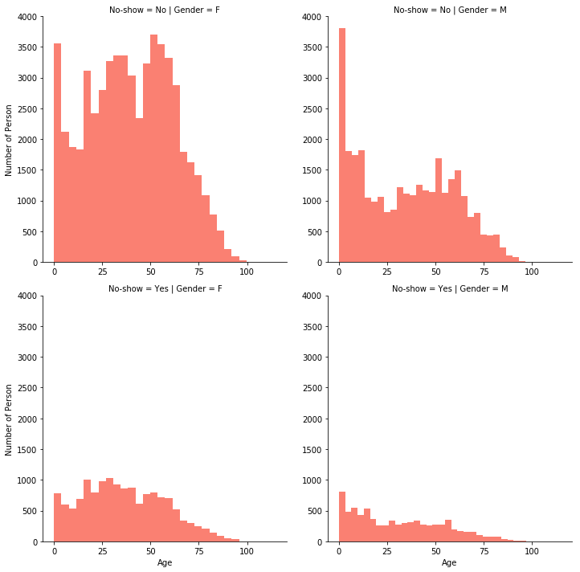

```python
#https://seaborn.pydata.org/generated/seaborn.FacetGrid.html#seaborn.FacetGrid
#Kind of Patiant that doesn't show up
g = sns.FacetGrid(df_clean, col="Gender",row='No-show',size=5, aspect=1)
g.map(plt.hist, 'Age', bins=30,color="salmon")
sns.set_style('dark')
sns.set_context(context='notebook')
sns.set(font_scale=1.5);
plt.figure(figsize=(10,8))
g.set_axis_labels("Age", "Number of Person");
```

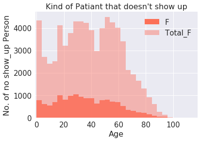

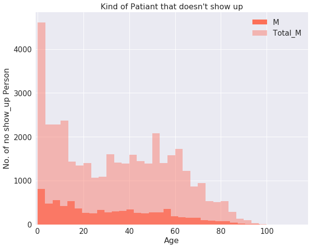

```python
#https://wellsr.com/python/seaborn-histogram-distplot-tutorial-for-python/
#https://www.machinelearningplus.com/plots/matplotlib-histogram-python-examples/
def draw(Ge,Total,gend):
    sns.distplot(Ge.Age, kde = False, bins = 30,label=gend,hist_kws={'alpha':.9}, color='tomato')
    sns.distplot(Total.Age, kde = False, bins = 30,label="Total_"+gend,hist_kws={'alpha':.5}, color="salmon")
    sns.set_style('darkgrid')
    plt.title("Kind of Patiant that doesn't show up", fontsize=16)
    plt.xlabel('Age', fontsize=16)
    plt.ylabel('No. of no show_up Person', fontsize=16)
    plt.xlim(-1,118)
    plt.legend(loc='upper right')
    sns.set_context(context='notebook')
    sns.set(font_scale=1.5)
    plt.figure(figsize=(10,8));
for gend in df_clean.Gender.unique():
    Ge=df_clean[(df_clean['Gender'] == gend) & (df_clean['No-show']=='Yes')]
    Total=df_clean[df_clean['Gender']==gend]
    draw(Ge,Total,gend)
```

##### - Number of Females with Age between 30:40 those haven't show_up are more than No. of males

### Research Question 2

#### - Does kind of disease affect patient show up for their scheduled appointment?

```python
df_test=df_clean[df_clean['No-show']=='Yes'].groupby(['Disease'],as_index=False)['Age'].count().sort_values(by=['Age'],ascending=False)
df_test
```

|  | Disease | Age |
| --- | --- | --- |
| 15 | Not_diagnosed | 9890 |
| 6 | Handicap | 7948 |
| 7 | Hypertension | 1397 |
| 8 | Hypertension Handicap | 1036 |
| 11 | Hypertension Diabetes | 681 |
| 12 | Hypertension Diabetes Handicap | 414 |
| 0 | Alcoholism | 241 |
| 1 | Alcoholism Handicap | 179 |
| 2 | Diabetes | 167 |
| 9 | Hypertension Alcoholism | 121 |
| 3 | Diabetes Handicap | 109 |
| 10 | Hypertension Alcoholism Handicap | 77 |
| 13 | Hypertension Diabetes Alcoholism | 28 |
| 14 | Hypertension Diabetes Alcoholism Handicap | 18 |
| 4 | Diabetes Alcoholism | 10 |
| 5 | Diabetes Alcoholism Handicap | 3 |

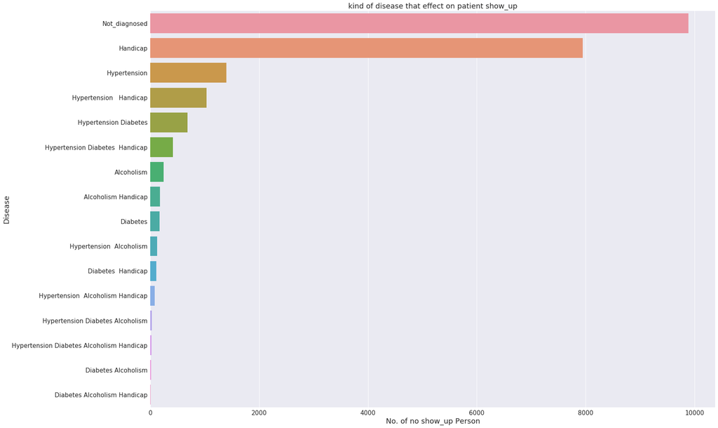

```python
plt.figure(figsize=(25,18))
sns.barplot(y="Disease", x="Age", data=df_test,  ci=None)
sns.set_style('dark')
plt.ylabel('Disease', fontsize=18)
plt.xlabel('No. of no show_up Person', fontsize=18)
plt.title("kind of disease that effect on patient show_up", fontsize=18)
plt.legend(loc='lower right')
sns.set_context(context='notebook')
sns.set(font_scale=2);
```

#### - Patients who have not been diagnosed and Handicap patients are the most patients that haven't show up.

### Research Question 3

#### - Does number of the days between the ScheduledDay and the AppointmentDay affect on patient show up for their scheduled appointment?

```python
#https://stackoverflow.com/questions/22132525/add-column-with-number-of-days-between-dates-in-dataframe-pandas count no of days
df_clean['Days']=(df_clean['AppointmentDay'] - df_clean['ScheduledDay']).dt.days.abs()
df_clean.Days.describe()
```

```
count    110526.000000
mean          9.881856
std          14.812392
min           0.000000
25%           1.000000
50%           3.000000
75%          14.000000
max         178.000000
Name: Days, dtype: float64
```

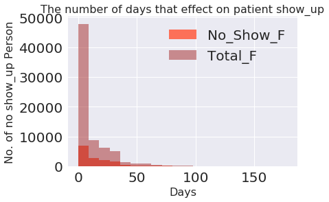

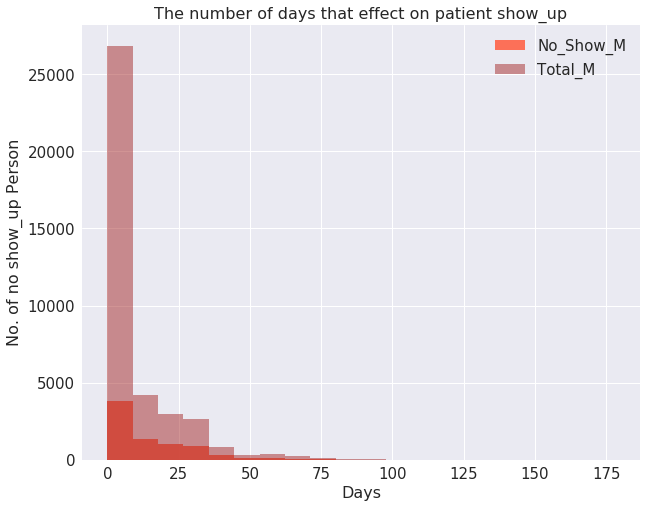

```python
def draw(Ge,Total,gend):
    sns.distplot(Ge.Days, kde = False, bins = 20,label="No_Show_"+gend,hist_kws={'alpha':.9}, color='tomato')
    sns.distplot(Total.Days, kde = False, bins = 20,label="Total_"+gend,hist_kws={'alpha':.5}, color="brown")
    sns.set_style('darkgrid')
    plt.title("The number of days that effect on patient show_up", fontsize=16)
    plt.xlabel('Days', fontsize=16)
    plt.ylabel('No. of no show_up Person', fontsize=16)
    plt.legend(loc='upper right')
    sns.set_context(context='notebook')
    sns.set(font_scale=1.5)
    plt.figure(figsize=(10,8));
for gend in df_clean.Gender.unique():
    Ge=df_clean[(df_clean['Gender'] == gend) & (df_clean['No-show']=='Yes')]
    Total=df_clean[df_clean['Gender']==gend]
    draw(Ge,Total,gend)
```

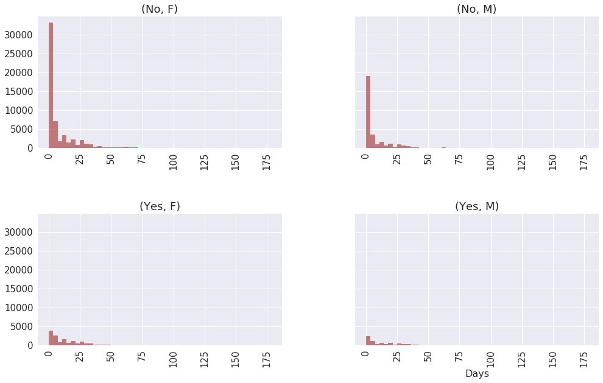

```python
#https://wellsr.com/python/python-create-histogram-from-pandas-dataframe/
df_clean.hist(by=["No-show","Gender"],column="Days",figsize=(16,10),color='brown',alpha=0.6,histtype='bar',bins=50,sharey=True)
plt.xlabel('Days', fontsize=16)
plt.ylabel('No. of Patients', fontsize=16)
plt.legend(loc='upper right')
plt.figure(figsize=(10,8))
sns.set_context(context='notebook')
sns.set(font_scale=1.5)
sns.set_style('darkgrid');
```

```python
df_D=df_clean.groupby(['No-show','Gender'])['Days'].describe()
df_D
```

| No-show | Gender | count | mean | std | min | 25% | 50% | 75% | max |
| --- | --- | --- | --- | --- | --- | --- | --- | --- | --- |
| No | F | 57245.0 | 8.891606 | 14.386740 | 0.0 | 1.0 | 1.0 | 12.0 | 178.0 |
|  | M | 30962.0 | 8.028034 | 13.460242 | 0.0 | 1.0 | 1.0 | 9.0 | 178.0 |
| Yes | F | 14594.0 | 15.153967 | 16.493746 | 0.0 | 3.0 | 10.0 | 22.0 | 178.0 |
|  | M | 7725.0 | 14.690097 | 16.392400 | 0.0 | 2.0 | 9.0 | 22.0 | 178.0 |

### Research Question 4

#### - Does number of SMS_received affect on patient show up for their scheduled appointment?

```python
Msg=df_clean[['Gender', "No-show","SMS_received"]].groupby(["No-show","SMS_received"],as_index=False).count().sort_values(by=['SMS_received'],ascending=False)
Msg
```

|  | No-show | SMS_received | Gender |
| --- | --- | --- | --- |
| 4 | No | 4 | 2 |
| 9 | Yes | 4 | 1 |
| 3 | No | 3 | 10 |
| 8 | Yes | 3 | 3 |
| 2 | No | 2 | 146 |
| 7 | Yes | 2 | 37 |
| 1 | No | 1 | 1676 |
| 6 | Yes | 1 | 366 |
| 0 | No | 0 | 86373 |
| 5 | Yes | 0 | 21912 |

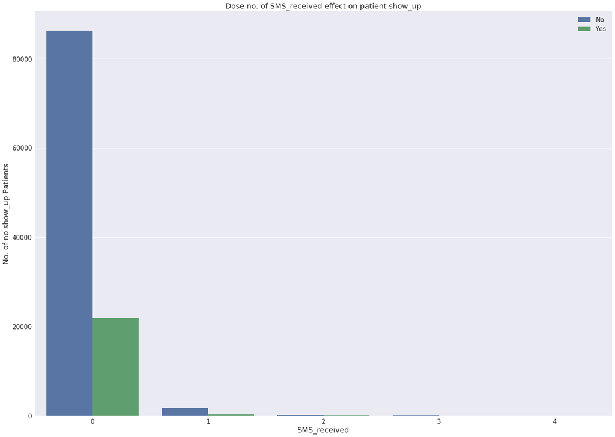

```python
plt.figure(figsize=(25,18))
sns.barplot(y="Gender", x="SMS_received",hue="No-show" , data=Msg,  ci=None)
sns.set_style('dark')
plt.ylabel('No. of no show_up Patients', fontsize=18)
plt.xlabel('SMS_received', fontsize=18)
plt.title("Dose no. of SMS_received effect on patient show_up", fontsize=18)
plt.legend(loc='upper right')
sns.set_context(context='notebook')
sns.set(font_scale=2);
```

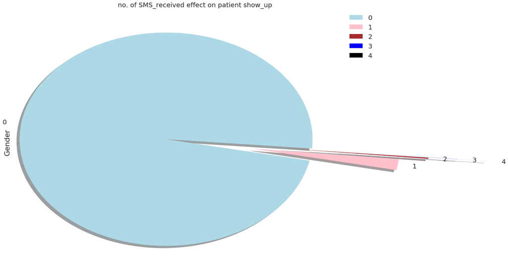

```python
#https://matplotlib.org/3.1.1/api/_as_gen/matplotlib.pyplot.pie.html
MSG=df_clean[df_clean["No-show"]=="Yes"].groupby(["SMS_received"]).count()
color=['lightblue','pink',"brown",'blue','black']
explodes= (0.2,0.4,0.6,0.8,1)
MSG.plot(y="Gender",kind='pie',fontsize=20,subplots=True,startangle=-5,shadow= True,explode=explodes,figsize=(20,15),
         colors =color )
plt.title('no. of SMS_received effect on patient show_up', fontsize=20)
sns.set_context(context='notebook')
```

##### - Most of Patients those haven't show up for their appointment,haven' recived Message.

### Conclusions

##### Limitations

> - I think variables must be more detailed to help in analytics.
> - categorical variables limitation,there is a limit to the kind of statistical analysis that can be performed on categorical data.

```python
from subprocess import call
call(['python', '-m', 'nbconvert', 'Investigate_a_Dataset.ipynb'])
```

```
0
```